# 000718_CaiLab_zaki_2024_000718_demo_ipynb

## Installing requirements

The cell below installs every Python package needed to run this notebook, at fully pinned versions, using [`uv`](https://github.com/astral-sh/uv) for fast resolution. In Colab the cell is collapsed by default — click the ▶ button to run it.

```python
# install cell skipped during CI (deps preinstalled into system Python)
```

> **⚠️ Restart runtime after install**

> The install may upgrade packages already loaded in the kernel. Go to **Runtime → Restart session**, then **Run all cells below** (skip this install cell on re-run).

# **Offline ensemble co-reactivation links memories across days**.

This tutorial shows how to access the data related to [DANDI:000718](https://dandiarchive.org/dandiset/000718/draft) using `pynwb`.

This dataset contains sessions with the 1-photon calcium imaging, calcium imaging segmentation, freezing behavior and behavioral video and other sessions with calcium imaging, calcium imaging segmentation, sleep behavior, EEG, EMG signals along with subject and session metadata.

Contents:

- Streaming an NWB file
- Access Subject and Session metadata
- Access Raw Imaging
- Access Processed Imaging
- Access Freezing Behavior
- Access EEG or Emg Traces
- Access Sleep Classification
- Access Week-long recordings and cross sessions cell registration

A schematic representation of the dataset:

[figure not shown]

A schematic representation NWB file structure for the conditioning sessions ("NeutralExposure", "FC", "Recall1", "Recall2", "Recall3"):

[figure not shown]

A schematic representation NWB file structure for the offline sessions:

[figure not shown]

A schematic representation NWB file structure for the week-long session:

[figure not shown]

# Select the subject and session you want to load

```python
dandiset_id = "000718"
subject_id = "Ca-EEG3-4"
session_id = "FC"
```

# Streaming an NWB file from DANDI

This section demonstrates how to access the files on the [DANDI Archive](https://dandiarchive.org) without downloading them. Based on the [Streaming NWB files](https://pynwb.readthedocs.io/en/stable/tutorials/advanced_io/streaming.html) tutorial from [PyNWB](https://pynwb.readthedocs.io/en/stable/#).

The `dandi.dandiapi.DandiAPIClient` can be used to get the S3 URL of the NWB file stored in the DANDI Archive. We will use `remfile` for streaming the file. You can read more about `remfile` at [this tutorial section](https://pynwb.readthedocs.io/en/stable/tutorials/advanced_io/streaming.html#method-3-remfile).

```python
from dandi.dandiapi import DandiAPIClient

nwbfile_path = f"sub-{subject_id}/sub-{subject_id}_ses-{session_id}_image+ophys.nwb"

dandiset_id = "000718"
with DandiAPIClient() as client:
    asset = client.get_dandiset(dandiset_id, 'draft').get_asset_by_path(nwbfile_path)
    s3_url = asset.get_content_url(follow_redirects=1, strip_query=False)

import h5py
import remfile
from pynwb import NWBHDF5IO

file = remfile.File(s3_url)
h5_file = h5py.File(file, "r")
io = NWBHDF5IO(file=h5_file, load_namespaces=True)
```

Importantly, the `session start time` is the reference time for all timestamps in the file. For instance, an event with a timestamp of 0 in the file means the event occurred exactly at the session start time.

The `session_start_time` is extracted from all_sessions.Session datajoint table.

```python
nwbfile = io.read()
nwbfile
```

root (NWBFile)

session_description: Fear Conditioning session: after a baseline period of 2 min, mouse received three 2s foot shocks of 0.25, with an intershock interval of 1 min. Then, 30 s after the final shock, the mice were removed and returned to the vivarium. Context: overhead external light, external fan at medium level, box fan on, even grid floor, acetic acid 1pct scent

identifier: 72b96b21-d9c9-45f0-bc84-53ee8de74c21

**session_start_time**

2022-09-19 09:18:41.001000-04:00

**timestamps_reference_time**

2022-09-19 09:18:41.001000-04:00

**file_create_date**

**0**

2024-12-10 14:41:01.239844+01:00

**experimenter**

('Zaki, Yosif',)

**related_publications**

('https://doi.org/10.1038/s41586-024-08168-4',)

**acquisition**

**OnePhotonSeries (OnePhotonSeries)**

resolution: -1.0

comments: no comments

description: Imaging data from Miniscope.

conversion: 1.0

offset: 0.0

unit: n.a.

**data**

HDF5 dataset

| Data type | uint8 |
| --- | --- |
| Shape | (8161, 608, 608) |
| Array size | 2.81 GiB |
| Chunk shape | (27, 608, 608) |
| Compression | gzip |
| Compression opts | 4 |
| Uncompressed size (bytes) | 3016827904 |
| Compressed size (bytes) | 2103869571 |
| Compression ratio | 1.4339424580232212 |

**timestamps**

HDF5 dataset

| Data type | float64 |
| --- | --- |
| Shape | (8161,) |
| Array size | 63.76 KiB |
| Chunk shape | (8161,) |
| Compression | gzip |
| Compression opts | 4 |
| Uncompressed size (bytes) | 65288 |
| Compressed size (bytes) | 27458 |
| Compression ratio | 2.3777405492024184 |

timestamps_unit: seconds

interval: 1

**dimension**

HDF5 dataset

| Data type | int32 |
| --- | --- |
| Shape | (2,) |
| Array size | 8.00 bytes |
| Chunk shape | None |
| Compression | None |
| Compression opts | None |
| Uncompressed size (bytes) | 8 |
| Compressed size (bytes) | 8 |
| Compression ratio | 1.0 |

[608 608]

**imaging_plane (ImagingPlane)**

**optical_channel**

**0 (OpticalChannel)**

description: Green channel of the microscope.

emission_lambda: 513.0

**1 (OpticalChannel)**

description: An optical channel of the microscope.

emission_lambda: nan

description: Imaging plane for Miniscope imaging data.

**device (Miniscope)**

description: The Miniscope is the head-mounted miniature microscope part of the UCLA Miniscope imaging platform.

compression: FFV1

deviceType: Miniscope_V4_BNO

frameRate: 30FPS

**framesPerFile**

int32

| Data type | int32 |
| --- | --- |
| Shape | () |
| Array size | 4.00 bytes |

1000

gain: 3.5

**led0**

int32

| Data type | int32 |
| --- | --- |
| Shape | () |
| Array size | 4.00 bytes |

1

**ROI**

HDF5 dataset

| Data type | int32 |
| --- | --- |
| Shape | (2,) |
| Array size | 8.00 bytes |
| Chunk shape | None |
| Compression | None |
| Compression opts | None |
| Uncompressed size (bytes) | 8 |
| Compressed size (bytes) | 8 |
| Compression ratio | 1.0 |

[608 608]

excitation_lambda: 496.0

imaging_rate: 30.0

indicator: GCaMP6f

location: CA1

conversion: 1.0

unit: meters

origin_coords_unit: meters

grid_spacing_unit: meters

**Video Ca_EEG3-4_FC (ImageSeries)**

resolution: -1.0

comments: no comments

description: Video recorded by camera.

conversion: 1.0

offset: 0.0

unit: Frames

**data**

HDF5 dataset

| Data type | uint8 |
| --- | --- |
| Shape | (0, 0, 0) |
| Array size | 0.00 bytes |
| Chunk shape | None |
| Compression | None |
| Compression opts | None |
| Uncompressed size (bytes) | 0 |
| Compressed size (bytes) | 0 |
| Compression ratio | undefined |

[]

**timestamps**

HDF5 dataset

| Data type | float64 |
| --- | --- |
| Shape | (8218,) |
| Array size | 64.20 KiB |
| Chunk shape | (8218,) |
| Compression | gzip |
| Compression opts | 4 |
| Uncompressed size (bytes) | 65744 |
| Compressed size (bytes) | 17933 |
| Compression ratio | 3.6660904477778398 |

timestamps_unit: seconds

interval: 1

**external_file**

HDF5 dataset

| Data type | object |
| --- | --- |
| Shape | (1,) |
| Array size | 8.00 bytes |
| Chunk shape | None |
| Compression | None |
| Compression opts | None |
| Uncompressed size (bytes) | 8 |
| Compressed size (bytes) | 16 |
| Compression ratio | 0.5 |

['sub-Ca-EEG3-4_ses-FC_image+ophys\\b0826a1c-4b6e-46f2-9ba3-64023e60ea01_external_file_0.wmv']

**starting_frame**

NumPy array

| Data type | int32 |
| --- | --- |
| Shape | (1,) |
| Array size | 4.00 bytes |

[0]

format: external

**stimulus**

**ShockStimuli (TimeIntervals)**

description: During aversive encoding, after a baseline period of 2 min, mice received three 2 s foot shocks of either amplitude 0.25 mA (low-shock) or 1.5 mA (high-shock), with an intershock interval of 1 min. All testing was done in Med Associates chambers.

**columns**

**start_time**

Start time of epoch, in seconds

**stop_time**

Stop time of epoch, in seconds

**shock_amplitude**

Shock amplitude in mA

**table**

| id | start_time | stop_time | shock_amplitude |
| --- | --- | --- | --- |
| 0 | 120.0 | 122.0 | 0.25 |
| 1 | 180.0 | 182.0 | 0.25 |
| 2 | 240.0 | 242.0 | 0.25 |

**keywords**

HDF5 dataset

| Data type | object |
| --- | --- |
| Shape | (8,) |
| Array size | 64.00 bytes |
| Chunk shape | None |
| Compression | None |
| Compression opts | None |
| Uncompressed size (bytes) | 64 |
| Compressed size (bytes) | 128 |
| Compression ratio | 0.5 |

['hippocampus' 'learning' 'memory-linking' 'ensemble' 'reactivation' 'co-activity' 'offline periods' 'aversive']

**processing**

**behavior (ProcessingModule)**

description: Contains behavior data

**MotionSeries (TimeSeries)**

starting_time: 0.006

rate: 30.0

resolution: -1.0

comments: no comments

description: ezTrack measures the motion of the animal by assessing the number of pixels of the behavioral video whose grayscale change exceeds a particular threshold from one frame to the next.

conversion: 1.0

offset: 0.0

unit: n.a

**data**

HDF5 dataset

| Data type | float64 |
| --- | --- |
| Shape | (8217,) |
| Array size | 64.20 KiB |
| Chunk shape | (8217,) |
| Compression | gzip |
| Compression opts | 4 |
| Uncompressed size (bytes) | 65736 |
| Compressed size (bytes) | 18241 |
| Compression ratio | 3.6037497944191657 |

starting_time_unit: seconds

**FreezingIntervals (TimeIntervals)**

description: Freezing behavior intervals generated using EzTrack software for file Ca_EEG3-4_FC.wmv. Parameters used include a motion cutoff of 10.0, freeze threshold of 200.0, and a minimum freeze duration of 15.0. - Freeze threshold: The maximum amount of motion the animal can display while still being classified as freezing. - Minimum freeze duration: The shortest time period the animal must remain below the freeze threshold to qualify as freezing. - Motion cutoff: The level of pixel intensity change required to register as motion.

**columns**

**start_time**

Start time of epoch, in seconds

**stop_time**

Stop time of epoch, in seconds

**timeseries**

index into a TimeSeries object

**table**

| id | start_time | stop_time | timeseries |
| --- | --- | --- | --- |
| 0 | 79.239333 | 80.172667 | [(2377, 28, MotionSeries pynwb.base.TimeSeries at 0x140346035752304\nFields:\n comments: no comments\n conversion: 1.0\n data: <HDF5 dataset "data": shape (8217,), type "<f8">\n description: ezTrack m… |
| 1 | 143.639333 | 144.706000 | [(4309, 32, MotionSeries pynwb.base.TimeSeries at 0x140346035752304\nFields:\n comments: no comments\n conversion: 1.0\n data: <HDF5 dataset "data": shape (8217,), type "<f8">\n description: ezTrack m… |
| 2 | 147.406000 | 148.172667 | [(4422, 23, MotionSeries pynwb.base.TimeSeries at 0x140346035752304\nFields:\n comments: no comments\n conversion: 1.0\n data: <HDF5 dataset "data": shape (8217,), type "<f8">\n description: ezTrack m… |
| 3 | 151.706000 | 152.206000 | [(4551, 15, MotionSeries pynwb.base.TimeSeries at 0x140346035752304\nFields:\n comments: no comments\n conversion: 1.0\n data: <HDF5 dataset "data": shape (8217,), type "<f8">\n description: ezTrack m… |

... and 17 more row(s).

**ophys (ProcessingModule)**

description: No description.

**Fluorescence (Fluorescence)**

**Baseline (RoiResponseSeries)**

resolution: -1.0

comments: no comments

description: description of baseline traces

conversion: 1.0

offset: 0.0

unit: n.a.

**data**

HDF5 dataset

| Data type | float64 |
| --- | --- |
| Shape | (4076, 783) |
| Array size | 24.35 MiB |
| Chunk shape | (2500, 500) |
| Compression | gzip |
| Compression opts | 4 |
| Uncompressed size (bytes) | 25532064 |
| Compressed size (bytes) | 184295 |
| Compression ratio | 138.53910306845003 |

**timestamps**

HDF5 dataset

| Data type | float64 |
| --- | --- |
| Shape | (4076,) |
| Array size | 31.84 KiB |
| Chunk shape | (4076,) |
| Compression | gzip |
| Compression opts | 4 |
| Uncompressed size (bytes) | 32608 |
| Compressed size (bytes) | 14600 |
| Compression ratio | 2.2334246575342465 |

timestamps_unit: seconds

interval: 1

**rois (DynamicTableRegion)**

description: The ROIs for ImagingPlane.

**table (PlaneSegmentation)**

description: Segmented ROIs

**imaging_plane (ImagingPlane)**

**optical_channel**

**0 (OpticalChannel)**

description: Green channel of the microscope.

emission_lambda: 513.0

**1 (OpticalChannel)**

description: An optical channel of the microscope.

emission_lambda: nan

description: Imaging plane for Miniscope imaging data.

**device (Miniscope)**

description: The Miniscope is the head-mounted miniature microscope part of the UCLA Miniscope imaging platform.

compression: FFV1

deviceType: Miniscope_V4_BNO

frameRate: 30FPS

**framesPerFile**

int32

| Data type | int32 |
| --- | --- |
| Shape | () |
| Array size | 4.00 bytes |

1000

gain: 3.5

**led0**

int32

| Data type | int32 |
| --- | --- |
| Shape | () |
| Array size | 4.00 bytes |

1

**ROI**

HDF5 dataset

| Data type | int32 |
| --- | --- |
| Shape | (2,) |
| Array size | 8.00 bytes |
| Chunk shape | None |
| Compression | None |
| Compression opts | None |
| Uncompressed size (bytes) | 8 |
| Compressed size (bytes) | 8 |
| Compression ratio | 1.0 |

[608 608]

excitation_lambda: 496.0

imaging_rate: 30.0

indicator: GCaMP6f

location: CA1

conversion: 1.0

unit: meters

origin_coords_unit: meters

grid_spacing_unit: meters

**columns**

**image_mask**

Image masks for each ROI.

**ROICentroids**

The x, y, (z) centroids of each ROI.

**table**

[output not shown]

... and 779 more row(s).

**Deconvolved (RoiResponseSeries)**

resolution: -1.0

comments: no comments

description: description of deconvolved traces

conversion: 1.0

offset: 0.0

unit: n.a.

**data**

HDF5 dataset

| Data type | float64 |
| --- | --- |
| Shape | (4076, 783) |
| Array size | 24.35 MiB |
| Chunk shape | (2500, 500) |
| Compression | gzip |
| Compression opts | 4 |
| Uncompressed size (bytes) | 25532064 |
| Compressed size (bytes) | 1066533 |
| Compression ratio | 23.93930989477119 |

**timestamps**

HDF5 dataset

| Data type | float64 |
| --- | --- |
| Shape | (4076,) |
| Array size | 31.84 KiB |
| Chunk shape | (4076,) |
| Compression | gzip |
| Compression opts | 4 |
| Uncompressed size (bytes) | 32608 |
| Compressed size (bytes) | 14600 |
| Compression ratio | 2.2334246575342465 |

timestamps_unit: seconds

interval: 1

**rois (DynamicTableRegion)**

description: The ROIs for ImagingPlane.

**table (PlaneSegmentation)**

description: Segmented ROIs

**imaging_plane (ImagingPlane)**

**optical_channel**

**0 (OpticalChannel)**

description: Green channel of the microscope.

emission_lambda: 513.0

**1 (OpticalChannel)**

description: An optical channel of the microscope.

emission_lambda: nan

description: Imaging plane for Miniscope imaging data.

**device (Miniscope)**

description: The Miniscope is the head-mounted miniature microscope part of the UCLA Miniscope imaging platform.

compression: FFV1

deviceType: Miniscope_V4_BNO

frameRate: 30FPS

**framesPerFile**

int32

| Data type | int32 |
| --- | --- |
| Shape | () |
| Array size | 4.00 bytes |

1000

gain: 3.5

**led0**

int32

| Data type | int32 |
| --- | --- |
| Shape | () |
| Array size | 4.00 bytes |

1

**ROI**

HDF5 dataset

| Data type | int32 |
| --- | --- |
| Shape | (2,) |
| Array size | 8.00 bytes |
| Chunk shape | None |
| Compression | None |
| Compression opts | None |
| Uncompressed size (bytes) | 8 |
| Compressed size (bytes) | 8 |
| Compression ratio | 1.0 |

[608 608]

excitation_lambda: 496.0

imaging_rate: 30.0

indicator: GCaMP6f

location: CA1

conversion: 1.0

unit: meters

origin_coords_unit: meters

grid_spacing_unit: meters

**columns**

**image_mask**

Image masks for each ROI.

**ROICentroids**

The x, y, (z) centroids of each ROI.

**table**

[output not shown]

... and 779 more row(s).

**Denoised (RoiResponseSeries)**

resolution: -1.0

comments: no comments

description: description of denoised traces

conversion: 1.0

offset: 0.0

unit: n.a.

**data**

HDF5 dataset

| Data type | float64 |
| --- | --- |
| Shape | (4076, 783) |
| Array size | 24.35 MiB |
| Chunk shape | (2500, 500) |
| Compression | gzip |
| Compression opts | 4 |
| Uncompressed size (bytes) | 25532064 |
| Compressed size (bytes) | 15571526 |
| Compression ratio | 1.6396635756829485 |

**timestamps**

HDF5 dataset

| Data type | float64 |
| --- | --- |
| Shape | (4076,) |
| Array size | 31.84 KiB |
| Chunk shape | (4076,) |
| Compression | gzip |
| Compression opts | 4 |
| Uncompressed size (bytes) | 32608 |
| Compressed size (bytes) | 14600 |
| Compression ratio | 2.2334246575342465 |

timestamps_unit: seconds

interval: 1

**rois (DynamicTableRegion)**

description: The ROIs for ImagingPlane.

**table (PlaneSegmentation)**

description: Segmented ROIs

**imaging_plane (ImagingPlane)**

**optical_channel**

**0 (OpticalChannel)**

description: Green channel of the microscope.

emission_lambda: 513.0

**1 (OpticalChannel)**

description: An optical channel of the microscope.

emission_lambda: nan

description: Imaging plane for Miniscope imaging data.

**device (Miniscope)**

description: The Miniscope is the head-mounted miniature microscope part of the UCLA Miniscope imaging platform.

compression: FFV1

deviceType: Miniscope_V4_BNO

frameRate: 30FPS

**framesPerFile**

int32

| Data type | int32 |
| --- | --- |
| Shape | () |
| Array size | 4.00 bytes |

1000

gain: 3.5

**led0**

int32

| Data type | int32 |
| --- | --- |
| Shape | () |
| Array size | 4.00 bytes |

1

**ROI**

HDF5 dataset

| Data type | int32 |
| --- | --- |
| Shape | (2,) |
| Array size | 8.00 bytes |
| Chunk shape | None |
| Compression | None |
| Compression opts | None |
| Uncompressed size (bytes) | 8 |
| Compressed size (bytes) | 8 |
| Compression ratio | 1.0 |

[608 608]

excitation_lambda: 496.0

imaging_rate: 30.0

indicator: GCaMP6f

location: CA1

conversion: 1.0

unit: meters

origin_coords_unit: meters

grid_spacing_unit: meters

**columns**

**image_mask**

Image masks for each ROI.

**ROICentroids**

The x, y, (z) centroids of each ROI.

**table**

[output not shown]

... and 779 more row(s).

**neuropil (RoiResponseSeries)**

resolution: -1.0

comments: no comments

description: Array of neuropil traces.

conversion: 1.0

offset: 0.0

unit: n.a.

**data**

HDF5 dataset

| Data type | float64 |
| --- | --- |
| Shape | (4076, 1) |
| Array size | 31.84 KiB |
| Chunk shape | (4076, 1) |
| Compression | gzip |
| Compression opts | 4 |
| Uncompressed size (bytes) | 32608 |
| Compressed size (bytes) | 30226 |
| Compression ratio | 1.0788063256798783 |

**timestamps**

HDF5 dataset

| Data type | float64 |
| --- | --- |
| Shape | (4076,) |
| Array size | 31.84 KiB |
| Chunk shape | (4076,) |
| Compression | gzip |
| Compression opts | 4 |
| Uncompressed size (bytes) | 32608 |
| Compressed size (bytes) | 14600 |
| Compression ratio | 2.2334246575342465 |

timestamps_unit: seconds

interval: 1

**rois (DynamicTableRegion)**

description: The ROIs for ImagingPlane.

**table (PlaneSegmentation)**

description: Segmented Background Components

**imaging_plane (ImagingPlane)**

**optical_channel**

**0 (OpticalChannel)**

description: Green channel of the microscope.

emission_lambda: 513.0

**1 (OpticalChannel)**

description: An optical channel of the microscope.

emission_lambda: nan

description: Imaging plane for Miniscope imaging data.

**device (Miniscope)**

description: The Miniscope is the head-mounted miniature microscope part of the UCLA Miniscope imaging platform.

compression: FFV1

deviceType: Miniscope_V4_BNO

frameRate: 30FPS

**framesPerFile**

int32

| Data type | int32 |
| --- | --- |
| Shape | () |
| Array size | 4.00 bytes |

1000

gain: 3.5

**led0**

int32

| Data type | int32 |
| --- | --- |
| Shape | () |
| Array size | 4.00 bytes |

1

**ROI**

HDF5 dataset

| Data type | int32 |
| --- | --- |
| Shape | (2,) |
| Array size | 8.00 bytes |
| Chunk shape | None |
| Compression | None |
| Compression opts | None |
| Uncompressed size (bytes) | 8 |
| Compressed size (bytes) | 8 |
| Compression ratio | 1.0 |

[608 608]

excitation_lambda: 496.0

imaging_rate: 30.0

indicator: GCaMP6f

location: CA1

conversion: 1.0

unit: meters

origin_coords_unit: meters

grid_spacing_unit: meters

**columns**

**image_mask**

Image masks for each ROI.

**table**

| id | image_mask |
| --- | --- |
| 0 | [[7.474159933559514e-06, 9.770764761843763e-06, 1.1064622531717202e-05, 1.1052706076913819e-05, 1.051694098347438e-05, 9.983973777637494e-06, 9.881747032661468e-06, 1.1402354298429403e-05, 1.286941033… |

**ImageSegmentation (ImageSegmentation)**

**BackgroundPlaneSegmentation (PlaneSegmentation)**

description: Segmented Background Components

**imaging_plane (ImagingPlane)**

**optical_channel**

**0 (OpticalChannel)**

description: Green channel of the microscope.

emission_lambda: 513.0

**1 (OpticalChannel)**

description: An optical channel of the microscope.

emission_lambda: nan

description: Imaging plane for Miniscope imaging data.

**device (Miniscope)**

description: The Miniscope is the head-mounted miniature microscope part of the UCLA Miniscope imaging platform.

compression: FFV1

deviceType: Miniscope_V4_BNO

frameRate: 30FPS

**framesPerFile**

int32

| Data type | int32 |
| --- | --- |
| Shape | () |
| Array size | 4.00 bytes |

1000

gain: 3.5

**led0**

int32

| Data type | int32 |
| --- | --- |
| Shape | () |
| Array size | 4.00 bytes |

1

**ROI**

HDF5 dataset

| Data type | int32 |
| --- | --- |
| Shape | (2,) |
| Array size | 8.00 bytes |
| Chunk shape | None |
| Compression | None |
| Compression opts | None |
| Uncompressed size (bytes) | 8 |
| Compressed size (bytes) | 8 |
| Compression ratio | 1.0 |

[608 608]

excitation_lambda: 496.0

imaging_rate: 30.0

indicator: GCaMP6f

location: CA1

conversion: 1.0

unit: meters

origin_coords_unit: meters

grid_spacing_unit: meters

**columns**

**image_mask**

Image masks for each ROI.

**table**

| id | image_mask |
| --- | --- |
| 0 | [[7.474159933559514e-06, 9.770764761843763e-06, 1.1064622531717202e-05, 1.1052706076913819e-05, 1.051694098347438e-05, 9.983973777637494e-06, 9.881747032661468e-06, 1.1402354298429403e-05, 1.286941033… |

**PlaneSegmentation (PlaneSegmentation)**

description: Segmented ROIs

**imaging_plane (ImagingPlane)**

**optical_channel**

**0 (OpticalChannel)**

description: Green channel of the microscope.

emission_lambda: 513.0

**1 (OpticalChannel)**

description: An optical channel of the microscope.

emission_lambda: nan

description: Imaging plane for Miniscope imaging data.

**device (Miniscope)**

description: The Miniscope is the head-mounted miniature microscope part of the UCLA Miniscope imaging platform.

compression: FFV1

deviceType: Miniscope_V4_BNO

frameRate: 30FPS

**framesPerFile**

int32

| Data type | int32 |
| --- | --- |
| Shape | () |
| Array size | 4.00 bytes |

1000

gain: 3.5

**led0**

int32

| Data type | int32 |
| --- | --- |
| Shape | () |
| Array size | 4.00 bytes |

1

**ROI**

HDF5 dataset

| Data type | int32 |
| --- | --- |
| Shape | (2,) |
| Array size | 8.00 bytes |
| Chunk shape | None |
| Compression | None |
| Compression opts | None |
| Uncompressed size (bytes) | 8 |
| Compressed size (bytes) | 8 |
| Compression ratio | 1.0 |

[608 608]

excitation_lambda: 496.0

imaging_rate: 30.0

indicator: GCaMP6f

location: CA1

conversion: 1.0

unit: meters

origin_coords_unit: meters

grid_spacing_unit: meters

**columns**

**image_mask**

Image masks for each ROI.

**ROICentroids**

The x, y, (z) centroids of each ROI.

**table**

| id | image_mask | ROICentroids |
| --- | --- | --- |
| 0 | [[0.0, 0.0, 0.0, 0.0, 0.0, 0.0, 0.0, 0.0, 0.0, 0.0, 0.0, 0.0, 0.0, 0.0, 0.0, 0.0, 0.0, 0.0, 0.0, 0.0, 0.0, 0.0, 0.0, 0.0, 0.0, 0.0, 0.0, 0.0, 0.0, 0.0, 0.0, 0.0, 0.0, 0.0, 0.0, 0.0, 0.0, 0.0, 0.0, 0.0… | [341, 39] |
| 1 | [[0.0, 0.0, 0.0, 0.0, 0.0, 0.0, 0.0, 0.0, 0.0, 0.0, 0.0, 0.0, 0.0, 0.0, 0.0, 0.0, 0.0, 0.0, 0.0, 0.0, 0.0, 0.0, 0.0, 0.0, 0.0, 0.0, 0.0, 0.0, 0.0, 0.0, 0.0, 0.0, 0.0, 0.0, 0.0, 0.0, 0.0, 0.0, 0.0, 0.0… | [444, 43] |
| 2 | [[0.0, 0.0, 0.0, 0.0, 0.0, 0.0, 0.0, 0.0, 0.0, 0.0, 0.0, 0.0, 0.0, 0.0, 0.0, 0.0, 0.0, 0.0, 0.0, 0.0, 0.0, 0.0, 0.0, 0.0, 0.0, 0.0, 0.0, 0.0, 0.0, 0.0, 0.0, 0.0, 0.0, 0.0, 0.0, 0.0, 0.0, 0.0, 0.0, 0.0… | [356, 62] |
| 3 | [[0.0, 0.0, 0.0, 0.0, 0.0, 0.0, 0.0, 0.0, 0.0, 0.0, 0.0, 0.0, 0.0, 0.0, 0.0, 0.0, 0.0, 0.0, 0.0, 0.0, 0.0, 0.0, 0.0, 0.0, 0.0, 0.0, 0.0, 0.0, 0.0, 0.0, 0.0, 0.0, 0.0, 0.0, 0.0, 0.0, 0.0, 0.0, 0.0, 0.0… | [405, 62] |

... and 779 more row(s).

**SegmentationImages (Images)**

description: The summary images of the segmentation.

**maximum_projection (GrayscaleImage)**

**devices**

**Microscope (Miniscope)**

description: The Miniscope is the head-mounted miniature microscope part of the UCLA Miniscope imaging platform.

compression: FFV1

deviceType: Miniscope_V4_BNO

frameRate: 30FPS

**framesPerFile**

int32

| Data type | int32 |
| --- | --- |
| Shape | () |
| Array size | 4.00 bytes |

1000

gain: 3.5

**led0**

int32

| Data type | int32 |
| --- | --- |
| Shape | () |
| Array size | 4.00 bytes |

1

**ROI**

HDF5 dataset

| Data type | int32 |
| --- | --- |
| Shape | (2,) |
| Array size | 8.00 bytes |
| Chunk shape | None |
| Compression | None |
| Compression opts | None |
| Uncompressed size (bytes) | 8 |
| Compressed size (bytes) | 8 |
| Compression ratio | 1.0 |

[608 608]

**imaging_planes**

**ImagingPlane (ImagingPlane)**

**optical_channel**

**0 (OpticalChannel)**

description: Green channel of the microscope.

emission_lambda: 513.0

**1 (OpticalChannel)**

description: An optical channel of the microscope.

emission_lambda: nan

description: Imaging plane for Miniscope imaging data.

**device (Miniscope)**

description: The Miniscope is the head-mounted miniature microscope part of the UCLA Miniscope imaging platform.

compression: FFV1

deviceType: Miniscope_V4_BNO

frameRate: 30FPS

**framesPerFile**

int32

| Data type | int32 |
| --- | --- |
| Shape | () |
| Array size | 4.00 bytes |

1000

gain: 3.5

**led0**

int32

| Data type | int32 |
| --- | --- |
| Shape | () |
| Array size | 4.00 bytes |

1

**ROI**

HDF5 dataset

| Data type | int32 |
| --- | --- |
| Shape | (2,) |
| Array size | 8.00 bytes |
| Chunk shape | None |
| Compression | None |
| Compression opts | None |
| Uncompressed size (bytes) | 8 |
| Compressed size (bytes) | 8 |
| Compression ratio | 1.0 |

[608 608]

excitation_lambda: 496.0

imaging_rate: 30.0

indicator: GCaMP6f

location: CA1

conversion: 1.0

unit: meters

origin_coords_unit: meters

grid_spacing_unit: meters

**subject (Subject)**

age: P12W/P18W

age__reference: birth

description: Adult C57BL/6J wild-type mice from Jackson Laboratories were used. Mice ordered from Jackson arrived group-housed in cages of 4 mice/cage and were singly housed for the experiment. Mice were ordered to arrive at 8-9 weeks of age and underwent behavioral testing about 4-6 weeks after the arrival date. All experimental procedures were approved by the Icahn School of Medicine at Mount Sinai's IACUC.

genotype: wild-type

sex: M

species: Mus musculus

subject_id: Ca_EEG3-4

strain: C57BL/6J

experiment_description: Simultaneous calcium imaging with Miniscopes and EEG/EMG experiment during retrospective memory-linking behavioral paradigm, to test whether ensemble co-reactivation is sleep-state specific. Mice were exposed to the neutral context for 10 min to explore. During aversive encoding, after a baseline period of 2 min, mice received three 2 s foot shocks of either amplitude 0.25 mA (low-shock) or 1.5 mA (high-shock), with an intershock interval of 1 min. Then, 30 s after the final shock, the mice were removed and returned to the vivarium. On the next 3 days, the mice were tested in the previously experienced aversive and neutral contexts, as well as a completely novel context that they had not been exposed to previously, for 5 min each. The features of the neutral and novel contexts were counter-balanced and were made up of different olfactory, auditory, lighting and tactile cues. The aversive context was always the same with distinct cues from the neutral and novel contexts. In the low- versus high-shock experiments mice were tested in the aversive context first, followed by testing in the neutral and novel context counter-balanced; half of the mice received neutral recall and then novel-context exposure the next day, and the other half received novel-context exposure and then neutral recall.

session_id: FC

lab: Cai

institution: Icahn School of Medicine at Mount Sinai

source_script: Created using NeuroConv v0.6.6

source_script_file_name: C:\Users\Utente\CatalystNeuro\neuroconv\src\neuroconv\basedatainterface.py

surgery: Mice were anaesthetized with 1 to 2% isoflurane for surgical procedures and placed into a stereotaxic frame (David Kopf Instruments). Eye ointment was applied to prevent desiccation, and the mice were kept on a heated pad to prevent hypothermia. Surgery was performed using aseptic technique. After surgery, carprofen (5mg per kg) was administered every day for the following 3 days, and ampicillin (20mg per kg) was administered every day for the next 7days. For calcium imaging experiments with EEG/EMG implants, mice underwent three serial procedures spaced around 2 weeks apart. During the first surgery, mice had 300 nl of AAV1-Syn-GCaMP6f injected into dorsal CA1 (AP, âˆ’2 mm; ML, +1.5 mm; DV, âˆ’1.2 mm), the incision was sutured after the surgery. Then, 2 weeks later during a second surgery, mice had their overlying cortex aspirated and a GRIN lens was implanted above the injection site. This involved aspirating the cortex with a 27-gauge blunt syringe needle attached to a vacuum pump, constantly irrigating with cortex buffer. When the striations of the corpus callosum were visible, a 30-gauge needle replaced the 27-gauge needle for finer-tuned aspiration. Once most of corpus callosum was removed, bleeding was controlled using surgical foam (Surgifoam), and a 1 mm diameter x 4 mm length GRIN lens (GRINTECH) was slowly lowered into the craniotomy. The lens was fixed with cyanoacrylate, and dental acrylic was applied to cement the implant in place and cover the exposed skull. The top of the exposed lens was covered with Kwik-Sil (World Precision Instruments) and then dental cement. During this same surgery, a wireless telemetry probe (HD-X02, Data Science International) was implanted with EEG and EMG wires. Two EMG wires were placed into the left trapezius muscle. One EEG wire was implanted between the skull and dura mater above the dorsal hippocampus on the contralateral hemisphere to the GRIN lens (left hemisphere; AP, âˆ’2 mm; ML, âˆ’1.5 mm), and a reference EEG wire was implanted between the skull and the dura on the right hemisphere overlying the prefrontal cortex (AP, +1.75 mm; ML, âˆ’0.5 mm). Cyanoacrylate and dental cement fixed the GRIN lens, anchor screw, and EEG wires in place. The telemetry probes were implanted during this second surgery to minimize the time mice needed to live with the implant. During the third procedure, the mice were returned to implant the baseplate. The Miniscope with an attached baseplate was lowered near the implanted lens, with the field of view monitored in real-time on a computer. The Miniscope was rotated until a well-exposed field of view was observed, at which point the baseplate was fixed to the implant with cyanoacrylate and dental cement.

virus: AAV1-Syn-GCaMP6f was injected into dorsal CA1 of the hippocampus on the right hemisphere (AP, âˆ’2 mm; ML, +1.5 mm; DV, âˆ’1.2 mm)

```python
nwbfile.session_start_time
```

```
datetime.datetime(2022, 9, 19, 9, 18, 41, 1000, tzinfo=tzoffset(None, -14400))
```

```python
nwbfile.experiment_description
```

```
'Simultaneous calcium imaging with Miniscopes and EEG/EMG experiment during retrospective memory-linking behavioral paradigm, to test whether ensemble co-reactivation is sleep-state specific. Mice were exposed to the neutral context for 10 min to explore. During aversive encoding, after a baseline p…
```

```python
nwbfile.session_description
```

```
'Fear Conditioning session: after a baseline period of 2 min, mouse received three 2s foot shocks of 0.25, with an intershock interval of 1 min. Then, 30 s after the final shock, the mice were removed and returned to the vivarium. Context: overhead external light, external fan at medium level, box f…
```

# Access subject

This section demonstrates how to access the Subject field in an NWB file.

The Subject field can be accessed as `nwbfile.subject`.

```python
nwbfile.subject
```

subject (Subject)

age: P12W/P18W

age__reference: birth

description: Adult C57BL/6J wild-type mice from Jackson Laboratories were used. Mice ordered from Jackson arrived group-housed in cages of 4 mice/cage and were singly housed for the experiment. Mice were ordered to arrive at 8-9 weeks of age and underwent behavioral testing about 4-6 weeks after the arrival date. All experimental procedures were approved by the Icahn School of Medicine at Mount Sinai's IACUC.

genotype: wild-type

sex: M

species: Mus musculus

subject_id: Ca_EEG3-4

strain: C57BL/6J

# Access OnePhoton Imaging

This section demonstraces how to access the raw One Photon imaging data.

`NWB` organizes data into different groups depending on the type of data. Groups can be thought of as folders within the file. Here are some of the groups within an NWBFile and the types of data they are intended to store:

- `acquisition`: raw, acquired data that should never change
- `processing`: processed data, typically the results of preprocessing algorithms and could change

## Raw OnePhoton Imaging

The raw OnePhoton imaging data is stored in `pynwb.ophys.OnePhotonSeries` objects (for each channel and plane separately) which is added to `nwbfile.acquisition`.

The data in OnePhotonSeries is stored as a three dimensional array: the first dimension is time (frame), the second and third dimensions represent x and y (width by height).

```python
photon_series_name = "OnePhotonSeries"
photon_series = nwbfile.acquisition[photon_series_name]
photon_series
```

OnePhotonSeries

resolution: -1.0

comments: no comments

description: Imaging data from Miniscope.

conversion: 1.0

offset: 0.0

unit: n.a.

**data**

HDF5 dataset

| Data type | uint8 |
| --- | --- |
| Shape | (8161, 608, 608) |
| Array size | 2.81 GiB |
| Chunk shape | (27, 608, 608) |
| Compression | gzip |
| Compression opts | 4 |
| Uncompressed size (bytes) | 3016827904 |
| Compressed size (bytes) | 2103869571 |
| Compression ratio | 1.4339424580232212 |

**timestamps**

HDF5 dataset

| Data type | float64 |
| --- | --- |
| Shape | (8161,) |
| Array size | 63.76 KiB |
| Chunk shape | (8161,) |
| Compression | gzip |
| Compression opts | 4 |
| Uncompressed size (bytes) | 65288 |
| Compressed size (bytes) | 27458 |
| Compression ratio | 2.3777405492024184 |

timestamps_unit: seconds

interval: 1

**dimension**

HDF5 dataset

| Data type | int32 |
| --- | --- |
| Shape | (2,) |
| Array size | 8.00 bytes |
| Chunk shape | None |
| Compression | None |
| Compression opts | None |
| Uncompressed size (bytes) | 8 |
| Compressed size (bytes) | 8 |
| Compression ratio | 1.0 |

[608 608]

**imaging_plane (ImagingPlane)**

**optical_channel**

**0 (OpticalChannel)**

description: Green channel of the microscope.

emission_lambda: 513.0

**1 (OpticalChannel)**

description: An optical channel of the microscope.

emission_lambda: nan

description: Imaging plane for Miniscope imaging data.

**device (Miniscope)**

description: The Miniscope is the head-mounted miniature microscope part of the UCLA Miniscope imaging platform.

compression: FFV1

deviceType: Miniscope_V4_BNO

frameRate: 30FPS

**framesPerFile**

int32

| Data type | int32 |
| --- | --- |
| Shape | () |
| Array size | 4.00 bytes |

1000

gain: 3.5

**led0**

int32

| Data type | int32 |
| --- | --- |
| Shape | () |
| Array size | 4.00 bytes |

1

**ROI**

HDF5 dataset

| Data type | int32 |
| --- | --- |
| Shape | (2,) |
| Array size | 8.00 bytes |
| Chunk shape | None |
| Compression | None |
| Compression opts | None |
| Uncompressed size (bytes) | 8 |
| Compressed size (bytes) | 8 |
| Compression ratio | 1.0 |

[608 608]

excitation_lambda: 496.0

imaging_rate: 30.0

indicator: GCaMP6f

location: CA1

conversion: 1.0

unit: meters

origin_coords_unit: meters

grid_spacing_unit: meters

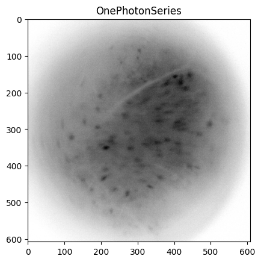

```python
# Visualize the imaging data.
from matplotlib import pyplot as plt
fig, ax = plt.subplots(nrows=1, ncols=1, sharex=True, sharey=True)
ax.imshow(photon_series.data[70], cmap="binary")
ax.set_title(photon_series_name)
plt.show()
```

```python
photon_series.timestamps[:100]
```

```
array([0.   , 0.034, 0.068, 0.1  , 0.133, 0.168, 0.201, 0.234, 0.268,
       0.302, 0.335, 0.369, 0.403, 0.435, 0.469, 0.504, 0.537, 0.571,
       0.605, 0.638, 0.671, 0.705, 0.738, 0.771, 0.806, 0.839, 0.873,
       0.907, 0.94 , 0.974, 1.007, 1.041, 1.074, 1.107, 1.142, 1.175,
       1.208, 1.243, 1.275, 1.308, 1.343, 1.376, 1.41 , 1.444, 1.476,
       1.511, 1.545, 1.578, 1.612, 1.645, 1.678, 1.712, 1.745, 1.778,
       1.813, 1.846, 1.879, 1.915, 1.947, 1.98 , 2.014, 2.048, 2.08 ,
       2.115, 2.148, 2.182, 2.215, 2.25 , 2.283, 2.316, 2.351, 2.384,
       2.417, 2.451, 2.484, 2.517, 2.552, 2.585, 2.618, 2.653, 2.685,
       2.718, 2.753, 2.786, 2.819, 2.853, 2.887, 2.921, 2.954, 2.988,
       3.021, 3.055, 3.089, 3.122, 3.155, 3.19 , 3.223, 3.257, 3.29 ,
       3.323])
```

```python
photon_series.dimension[:]
```

```
array([608, 608], dtype=int32)
```

Imaging metadata include information on the **device** used to acquire the image and the **optical channel** specs contained in the imaging plane object

```python
nwbfile.imaging_planes["ImagingPlane"]
```

ImagingPlane

**optical_channel**

**0 (OpticalChannel)**

description: Green channel of the microscope.

emission_lambda: 513.0

**1 (OpticalChannel)**

description: An optical channel of the microscope.

emission_lambda: nan

description: Imaging plane for Miniscope imaging data.

**device (Miniscope)**

description: The Miniscope is the head-mounted miniature microscope part of the UCLA Miniscope imaging platform.

compression: FFV1

deviceType: Miniscope_V4_BNO

frameRate: 30FPS

**framesPerFile**

int32

| Data type | int32 |
| --- | --- |
| Shape | () |
| Array size | 4.00 bytes |

1000

gain: 3.5

**led0**

int32

| Data type | int32 |
| --- | --- |
| Shape | () |
| Array size | 4.00 bytes |

1

**ROI**

HDF5 dataset

| Data type | int32 |
| --- | --- |
| Shape | (2,) |
| Array size | 8.00 bytes |
| Chunk shape | None |
| Compression | None |
| Compression opts | None |
| Uncompressed size (bytes) | 8 |
| Compressed size (bytes) | 8 |
| Compression ratio | 1.0 |

[608 608]

excitation_lambda: 496.0

imaging_rate: 30.0

indicator: GCaMP6f

location: CA1

conversion: 1.0

unit: meters

origin_coords_unit: meters

grid_spacing_unit: meters

```python
nwbfile.devices["Microscope"]
```

Microscope (Miniscope)

description: The Miniscope is the head-mounted miniature microscope part of the UCLA Miniscope imaging platform.

compression: FFV1

deviceType: Miniscope_V4_BNO

frameRate: 30FPS

**framesPerFile**

int32

| Data type | int32 |
| --- | --- |
| Shape | () |
| Array size | 4.00 bytes |

1000

gain: 3.5

**led0**

int32

| Data type | int32 |
| --- | --- |
| Shape | () |
| Array size | 4.00 bytes |

1

**ROI**

HDF5 dataset

| Data type | int32 |
| --- | --- |
| Shape | (2,) |
| Array size | 8.00 bytes |
| Chunk shape | None |
| Compression | None |
| Compression opts | None |
| Uncompressed size (bytes) | 8 |
| Compressed size (bytes) | 8 |
| Compression ratio | 1.0 |

[608 608]

## Accessing the segmentation data

The segmentation output for the One Photon Imaging data is stored in `nwbfile.processing["ophys"]`.

In NWB, the PlaneSegmentation class stores the detected regions of interest in the OnePhotonSeries data. The ImageSegmentation can contain multiple `PlaneSegmentation` tables, so that we can store results of different segmentation algorithms or different segmentation classes.

```python
nwbfile.processing["ophys"]
```

ophys (ProcessingModule)

description: No description.

**Fluorescence (Fluorescence)**

**Baseline (RoiResponseSeries)**

resolution: -1.0

comments: no comments

description: description of baseline traces

conversion: 1.0

offset: 0.0

unit: n.a.

**data**

HDF5 dataset

| Data type | float64 |
| --- | --- |
| Shape | (4076, 783) |
| Array size | 24.35 MiB |
| Chunk shape | (2500, 500) |
| Compression | gzip |
| Compression opts | 4 |
| Uncompressed size (bytes) | 25532064 |
| Compressed size (bytes) | 184295 |
| Compression ratio | 138.53910306845003 |

**timestamps**

HDF5 dataset

| Data type | float64 |
| --- | --- |
| Shape | (4076,) |
| Array size | 31.84 KiB |
| Chunk shape | (4076,) |
| Compression | gzip |
| Compression opts | 4 |
| Uncompressed size (bytes) | 32608 |
| Compressed size (bytes) | 14600 |
| Compression ratio | 2.2334246575342465 |

timestamps_unit: seconds

interval: 1

**rois (DynamicTableRegion)**

description: The ROIs for ImagingPlane.

**table (PlaneSegmentation)**

description: Segmented ROIs

**imaging_plane (ImagingPlane)**

**optical_channel**

**0 (OpticalChannel)**

description: Green channel of the microscope.

emission_lambda: 513.0

**1 (OpticalChannel)**

description: An optical channel of the microscope.

emission_lambda: nan

description: Imaging plane for Miniscope imaging data.

**device (Miniscope)**

description: The Miniscope is the head-mounted miniature microscope part of the UCLA Miniscope imaging platform.

compression: FFV1

deviceType: Miniscope_V4_BNO

frameRate: 30FPS

**framesPerFile**

int32

| Data type | int32 |
| --- | --- |
| Shape | () |
| Array size | 4.00 bytes |

1000

gain: 3.5

**led0**

int32

| Data type | int32 |
| --- | --- |
| Shape | () |
| Array size | 4.00 bytes |

1

**ROI**

HDF5 dataset

| Data type | int32 |
| --- | --- |
| Shape | (2,) |
| Array size | 8.00 bytes |
| Chunk shape | None |
| Compression | None |
| Compression opts | None |
| Uncompressed size (bytes) | 8 |
| Compressed size (bytes) | 8 |
| Compression ratio | 1.0 |

[608 608]

excitation_lambda: 496.0

imaging_rate: 30.0

indicator: GCaMP6f

location: CA1

conversion: 1.0

unit: meters

origin_coords_unit: meters

grid_spacing_unit: meters

**columns**

**image_mask**

Image masks for each ROI.

**ROICentroids**

The x, y, (z) centroids of each ROI.

**table**

[output not shown]

... and 779 more row(s).

**Deconvolved (RoiResponseSeries)**

resolution: -1.0

comments: no comments

description: description of deconvolved traces

conversion: 1.0

offset: 0.0

unit: n.a.

**data**

HDF5 dataset

| Data type | float64 |
| --- | --- |
| Shape | (4076, 783) |
| Array size | 24.35 MiB |
| Chunk shape | (2500, 500) |
| Compression | gzip |
| Compression opts | 4 |
| Uncompressed size (bytes) | 25532064 |
| Compressed size (bytes) | 1066533 |
| Compression ratio | 23.93930989477119 |

**timestamps**

HDF5 dataset

| Data type | float64 |
| --- | --- |
| Shape | (4076,) |
| Array size | 31.84 KiB |
| Chunk shape | (4076,) |
| Compression | gzip |
| Compression opts | 4 |
| Uncompressed size (bytes) | 32608 |
| Compressed size (bytes) | 14600 |
| Compression ratio | 2.2334246575342465 |

timestamps_unit: seconds

interval: 1

**rois (DynamicTableRegion)**

description: The ROIs for ImagingPlane.

**table (PlaneSegmentation)**

description: Segmented ROIs

**imaging_plane (ImagingPlane)**

**optical_channel**

**0 (OpticalChannel)**

description: Green channel of the microscope.

emission_lambda: 513.0

**1 (OpticalChannel)**

description: An optical channel of the microscope.

emission_lambda: nan

description: Imaging plane for Miniscope imaging data.

**device (Miniscope)**

description: The Miniscope is the head-mounted miniature microscope part of the UCLA Miniscope imaging platform.

compression: FFV1

deviceType: Miniscope_V4_BNO

frameRate: 30FPS

**framesPerFile**

int32

| Data type | int32 |
| --- | --- |
| Shape | () |
| Array size | 4.00 bytes |

1000

gain: 3.5

**led0**

int32

| Data type | int32 |
| --- | --- |
| Shape | () |
| Array size | 4.00 bytes |

1

**ROI**

HDF5 dataset

| Data type | int32 |
| --- | --- |
| Shape | (2,) |
| Array size | 8.00 bytes |
| Chunk shape | None |
| Compression | None |
| Compression opts | None |
| Uncompressed size (bytes) | 8 |
| Compressed size (bytes) | 8 |
| Compression ratio | 1.0 |

[608 608]

excitation_lambda: 496.0

imaging_rate: 30.0

indicator: GCaMP6f

location: CA1

conversion: 1.0

unit: meters

origin_coords_unit: meters

grid_spacing_unit: meters

**columns**

**image_mask**

Image masks for each ROI.

**ROICentroids**

The x, y, (z) centroids of each ROI.

**table**

[output not shown]

... and 779 more row(s).

**Denoised (RoiResponseSeries)**

resolution: -1.0

comments: no comments

description: description of denoised traces

conversion: 1.0

offset: 0.0

unit: n.a.

**data**

HDF5 dataset

| Data type | float64 |
| --- | --- |
| Shape | (4076, 783) |
| Array size | 24.35 MiB |
| Chunk shape | (2500, 500) |
| Compression | gzip |
| Compression opts | 4 |
| Uncompressed size (bytes) | 25532064 |
| Compressed size (bytes) | 15571526 |
| Compression ratio | 1.6396635756829485 |

**timestamps**

HDF5 dataset

| Data type | float64 |
| --- | --- |
| Shape | (4076,) |
| Array size | 31.84 KiB |
| Chunk shape | (4076,) |
| Compression | gzip |
| Compression opts | 4 |
| Uncompressed size (bytes) | 32608 |
| Compressed size (bytes) | 14600 |
| Compression ratio | 2.2334246575342465 |

timestamps_unit: seconds

interval: 1

**rois (DynamicTableRegion)**

description: The ROIs for ImagingPlane.

**table (PlaneSegmentation)**

description: Segmented ROIs

**imaging_plane (ImagingPlane)**

**optical_channel**

**0 (OpticalChannel)**

description: Green channel of the microscope.

emission_lambda: 513.0

**1 (OpticalChannel)**

description: An optical channel of the microscope.

emission_lambda: nan

description: Imaging plane for Miniscope imaging data.

**device (Miniscope)**

description: The Miniscope is the head-mounted miniature microscope part of the UCLA Miniscope imaging platform.

compression: FFV1

deviceType: Miniscope_V4_BNO

frameRate: 30FPS

**framesPerFile**

int32

| Data type | int32 |
| --- | --- |
| Shape | () |
| Array size | 4.00 bytes |

1000

gain: 3.5

**led0**

int32

| Data type | int32 |
| --- | --- |
| Shape | () |
| Array size | 4.00 bytes |

1

**ROI**

HDF5 dataset

| Data type | int32 |
| --- | --- |
| Shape | (2,) |
| Array size | 8.00 bytes |
| Chunk shape | None |
| Compression | None |
| Compression opts | None |
| Uncompressed size (bytes) | 8 |
| Compressed size (bytes) | 8 |
| Compression ratio | 1.0 |

[608 608]

excitation_lambda: 496.0

imaging_rate: 30.0

indicator: GCaMP6f

location: CA1

conversion: 1.0

unit: meters

origin_coords_unit: meters

grid_spacing_unit: meters

**columns**

**image_mask**

Image masks for each ROI.

**ROICentroids**

The x, y, (z) centroids of each ROI.

**table**

[output not shown]

... and 779 more row(s).

**neuropil (RoiResponseSeries)**

resolution: -1.0

comments: no comments

description: Array of neuropil traces.

conversion: 1.0

offset: 0.0

unit: n.a.

**data**

HDF5 dataset

| Data type | float64 |
| --- | --- |
| Shape | (4076, 1) |
| Array size | 31.84 KiB |
| Chunk shape | (4076, 1) |
| Compression | gzip |
| Compression opts | 4 |
| Uncompressed size (bytes) | 32608 |
| Compressed size (bytes) | 30226 |
| Compression ratio | 1.0788063256798783 |

**timestamps**

HDF5 dataset

| Data type | float64 |
| --- | --- |
| Shape | (4076,) |
| Array size | 31.84 KiB |
| Chunk shape | (4076,) |
| Compression | gzip |
| Compression opts | 4 |
| Uncompressed size (bytes) | 32608 |
| Compressed size (bytes) | 14600 |
| Compression ratio | 2.2334246575342465 |

timestamps_unit: seconds

interval: 1

**rois (DynamicTableRegion)**

description: The ROIs for ImagingPlane.

**table (PlaneSegmentation)**

description: Segmented Background Components

**imaging_plane (ImagingPlane)**

**optical_channel**

**0 (OpticalChannel)**

description: Green channel of the microscope.

emission_lambda: 513.0

**1 (OpticalChannel)**

description: An optical channel of the microscope.

emission_lambda: nan

description: Imaging plane for Miniscope imaging data.

**device (Miniscope)**

description: The Miniscope is the head-mounted miniature microscope part of the UCLA Miniscope imaging platform.

compression: FFV1

deviceType: Miniscope_V4_BNO

frameRate: 30FPS

**framesPerFile**

int32

| Data type | int32 |
| --- | --- |
| Shape | () |
| Array size | 4.00 bytes |

1000

gain: 3.5

**led0**

int32

| Data type | int32 |
| --- | --- |
| Shape | () |
| Array size | 4.00 bytes |

1

**ROI**

HDF5 dataset

| Data type | int32 |
| --- | --- |
| Shape | (2,) |
| Array size | 8.00 bytes |
| Chunk shape | None |
| Compression | None |
| Compression opts | None |
| Uncompressed size (bytes) | 8 |
| Compressed size (bytes) | 8 |
| Compression ratio | 1.0 |

[608 608]

excitation_lambda: 496.0

imaging_rate: 30.0

indicator: GCaMP6f

location: CA1

conversion: 1.0

unit: meters

origin_coords_unit: meters

grid_spacing_unit: meters

**columns**

**image_mask**

Image masks for each ROI.

**table**

| id | image_mask |
| --- | --- |
| 0 | [[7.474159933559514e-06, 9.770764761843763e-06, 1.1064622531717202e-05, 1.1052706076913819e-05, 1.051694098347438e-05, 9.983973777637494e-06, 9.881747032661468e-06, 1.1402354298429403e-05, 1.286941033… |

**ImageSegmentation (ImageSegmentation)**

**BackgroundPlaneSegmentation (PlaneSegmentation)**

description: Segmented Background Components

**imaging_plane (ImagingPlane)**

**optical_channel**

**0 (OpticalChannel)**

description: Green channel of the microscope.

emission_lambda: 513.0

**1 (OpticalChannel)**

description: An optical channel of the microscope.

emission_lambda: nan

description: Imaging plane for Miniscope imaging data.

**device (Miniscope)**

description: The Miniscope is the head-mounted miniature microscope part of the UCLA Miniscope imaging platform.

compression: FFV1

deviceType: Miniscope_V4_BNO

frameRate: 30FPS

**framesPerFile**

int32

| Data type | int32 |
| --- | --- |
| Shape | () |
| Array size | 4.00 bytes |

1000

gain: 3.5

**led0**

int32

| Data type | int32 |
| --- | --- |
| Shape | () |
| Array size | 4.00 bytes |

1

**ROI**

HDF5 dataset

| Data type | int32 |
| --- | --- |
| Shape | (2,) |
| Array size | 8.00 bytes |
| Chunk shape | None |
| Compression | None |
| Compression opts | None |
| Uncompressed size (bytes) | 8 |
| Compressed size (bytes) | 8 |
| Compression ratio | 1.0 |

[608 608]

excitation_lambda: 496.0

imaging_rate: 30.0

indicator: GCaMP6f

location: CA1

conversion: 1.0

unit: meters

origin_coords_unit: meters

grid_spacing_unit: meters

**columns**

**image_mask**

Image masks for each ROI.

**table**

| id | image_mask |
| --- | --- |
| 0 | [[7.474159933559514e-06, 9.770764761843763e-06, 1.1064622531717202e-05, 1.1052706076913819e-05, 1.051694098347438e-05, 9.983973777637494e-06, 9.881747032661468e-06, 1.1402354298429403e-05, 1.286941033… |

**PlaneSegmentation (PlaneSegmentation)**

description: Segmented ROIs

**imaging_plane (ImagingPlane)**

**optical_channel**

**0 (OpticalChannel)**

description: Green channel of the microscope.

emission_lambda: 513.0

**1 (OpticalChannel)**

description: An optical channel of the microscope.

emission_lambda: nan

description: Imaging plane for Miniscope imaging data.

**device (Miniscope)**

description: The Miniscope is the head-mounted miniature microscope part of the UCLA Miniscope imaging platform.

compression: FFV1

deviceType: Miniscope_V4_BNO

frameRate: 30FPS

**framesPerFile**

int32

| Data type | int32 |
| --- | --- |
| Shape | () |
| Array size | 4.00 bytes |

1000

gain: 3.5

**led0**

int32

| Data type | int32 |
| --- | --- |
| Shape | () |
| Array size | 4.00 bytes |

1

**ROI**

HDF5 dataset

| Data type | int32 |
| --- | --- |
| Shape | (2,) |
| Array size | 8.00 bytes |
| Chunk shape | None |
| Compression | None |
| Compression opts | None |
| Uncompressed size (bytes) | 8 |
| Compressed size (bytes) | 8 |
| Compression ratio | 1.0 |

[608 608]

excitation_lambda: 496.0

imaging_rate: 30.0

indicator: GCaMP6f

location: CA1

conversion: 1.0

unit: meters

origin_coords_unit: meters

grid_spacing_unit: meters

**columns**

**image_mask**

Image masks for each ROI.

**ROICentroids**

The x, y, (z) centroids of each ROI.

**table**

| id | image_mask | ROICentroids |
| --- | --- | --- |
| 0 | [[0.0, 0.0, 0.0, 0.0, 0.0, 0.0, 0.0, 0.0, 0.0, 0.0, 0.0, 0.0, 0.0, 0.0, 0.0, 0.0, 0.0, 0.0, 0.0, 0.0, 0.0, 0.0, 0.0, 0.0, 0.0, 0.0, 0.0, 0.0, 0.0, 0.0, 0.0, 0.0, 0.0, 0.0, 0.0, 0.0, 0.0, 0.0, 0.0, 0.0… | [341, 39] |
| 1 | [[0.0, 0.0, 0.0, 0.0, 0.0, 0.0, 0.0, 0.0, 0.0, 0.0, 0.0, 0.0, 0.0, 0.0, 0.0, 0.0, 0.0, 0.0, 0.0, 0.0, 0.0, 0.0, 0.0, 0.0, 0.0, 0.0, 0.0, 0.0, 0.0, 0.0, 0.0, 0.0, 0.0, 0.0, 0.0, 0.0, 0.0, 0.0, 0.0, 0.0… | [444, 43] |
| 2 | [[0.0, 0.0, 0.0, 0.0, 0.0, 0.0, 0.0, 0.0, 0.0, 0.0, 0.0, 0.0, 0.0, 0.0, 0.0, 0.0, 0.0, 0.0, 0.0, 0.0, 0.0, 0.0, 0.0, 0.0, 0.0, 0.0, 0.0, 0.0, 0.0, 0.0, 0.0, 0.0, 0.0, 0.0, 0.0, 0.0, 0.0, 0.0, 0.0, 0.0… | [356, 62] |
| 3 | [[0.0, 0.0, 0.0, 0.0, 0.0, 0.0, 0.0, 0.0, 0.0, 0.0, 0.0, 0.0, 0.0, 0.0, 0.0, 0.0, 0.0, 0.0, 0.0, 0.0, 0.0, 0.0, 0.0, 0.0, 0.0, 0.0, 0.0, 0.0, 0.0, 0.0, 0.0, 0.0, 0.0, 0.0, 0.0, 0.0, 0.0, 0.0, 0.0, 0.0… | [405, 62] |

... and 779 more row(s).

**SegmentationImages (Images)**

description: The summary images of the segmentation.

**maximum_projection (GrayscaleImage)**

### The SegmentationImages data interface

SegmentationImages data interface contains summary images such as the Maximum Projection Image

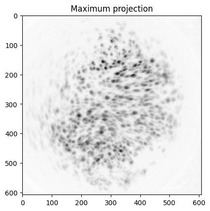

```python
fig, ax = plt.subplots(nrows=1, ncols=1, sharex=True, sharey=True)
max_projection_image = nwbfile.processing["ophys"]["SegmentationImages"].images["maximum_projection"]
ax.imshow(max_projection_image.data[:], cmap="binary")
ax.set_title("Maximum projection")
plt.show()
```

### The ImageSegmentation data interface

ImageSegmentation data interface contains the spatial data of the segmentation output. The PlaneSegmentation stores masks of an image that represent different regions of interest (ROIs). All segmentation for a given imaging plane is stored together, with storage for multiple imaging planes (masks) supported. Each ROI is stored in its own subgroup, with the ROI group containing both a 2D mask and a list of pixels that make up this mask.

```python
plane_segmentation_names = list(nwbfile.processing["ophys"]["ImageSegmentation"].plane_segmentations.keys())
_ = [print(name) for name in nwbfile.processing["ophys"]["ImageSegmentation"].plane_segmentations.keys()]
```

```
BackgroundPlaneSegmentation
PlaneSegmentation
```

```python
plane_seg_name = "PlaneSegmentation"
plane_segmentation = nwbfile.processing["ophys"]["ImageSegmentation"].plane_segmentations[plane_seg_name]
plane_segmentation.to_dataframe()
```

| id | image_mask | ROICentroids |
| --- | --- | --- |
| 0 | [[0.0, 0.0, 0.0, 0.0, 0.0, 0.0, 0.0, 0.0, 0.0,... | [341, 39] |
| 1 | [[0.0, 0.0, 0.0, 0.0, 0.0, 0.0, 0.0, 0.0, 0.0,... | [444, 43] |
| 2 | [[0.0, 0.0, 0.0, 0.0, 0.0, 0.0, 0.0, 0.0, 0.0,... | [356, 62] |
| 3 | [[0.0, 0.0, 0.0, 0.0, 0.0, 0.0, 0.0, 0.0, 0.0,... | [405, 62] |
| 4 | [[0.0, 0.0, 0.0, 0.0, 0.0, 0.0, 0.0, 0.0, 0.0,... | [380, 64] |
| ... | ... | ... |
| 778 | [[0.0, 0.0, 0.0, 0.0, 0.0, 0.0, 0.0, 0.0, 0.0,... | [315, 530] |
| 779 | [[0.0, 0.0, 0.0, 0.0, 0.0, 0.0, 0.0, 0.0, 0.0,... | [327, 529] |
| 780 | [[0.0, 0.0, 0.0, 0.0, 0.0, 0.0, 0.0, 0.0, 0.0,... | [277, 530] |
| 781 | [[0.0, 0.0, 0.0, 0.0, 0.0, 0.0, 0.0, 0.0, 0.0,... | [372, 533] |
| 782 | [[0.0, 0.0, 0.0, 0.0, 0.0, 0.0, 0.0, 0.0, 0.0,... | [281, 542] |

783 rows × 2 columns

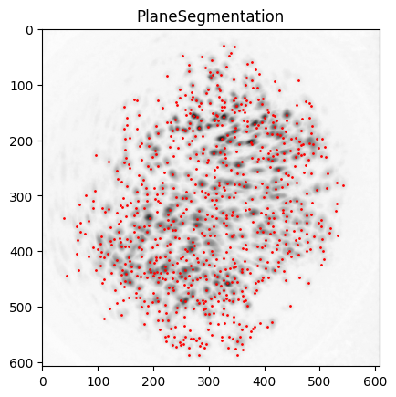

```python
fig, ax = plt.subplots(nrows=1, ncols=1, sharex=True, sharey=True)
ax.imshow(max_projection_image.data[:], cmap="binary")
for roi_centroid in plane_segmentation["ROICentroids"]:
    ax.scatter(roi_centroid[1], roi_centroid[0],c="red", s=1)
ax.set_title(plane_seg_name)
plt.show()
```

## The Fluorescence data interface

The Fluorescence data interface stores the fluorescence information about a region of interest (ROI): the ROI response series. Each ROI response series stores ROI responses over an imaging plane. Each column in data should correspond to the signal from one ROI.

```python
import pandas as pd
import warnings
warnings.simplefilter(action='ignore', category=pd.errors.PerformanceWarning)

roi_response_series_names = [name for name in nwbfile.processing["ophys"]["Fluorescence"].roi_response_series.keys()]
roi_response_series_names
```

```
['Baseline', 'Deconvolved', 'Denoised', 'neuropil']
```

```python
roi_response_series = nwbfile.processing["ophys"]["Fluorescence"]["Denoised"]
roi_response_series
```

Denoised (RoiResponseSeries)

resolution: -1.0

comments: no comments

description: description of denoised traces

conversion: 1.0

offset: 0.0

unit: n.a.

**data**

HDF5 dataset

| Data type | float64 |
| --- | --- |
| Shape | (4076, 783) |
| Array size | 24.35 MiB |
| Chunk shape | (2500, 500) |
| Compression | gzip |
| Compression opts | 4 |
| Uncompressed size (bytes) | 25532064 |
| Compressed size (bytes) | 15571526 |
| Compression ratio | 1.6396635756829485 |

**timestamps**

HDF5 dataset

| Data type | float64 |
| --- | --- |
| Shape | (4076,) |
| Array size | 31.84 KiB |
| Chunk shape | (4076,) |
| Compression | gzip |
| Compression opts | 4 |
| Uncompressed size (bytes) | 32608 |
| Compressed size (bytes) | 14600 |
| Compression ratio | 2.2334246575342465 |

timestamps_unit: seconds

interval: 1

**rois (DynamicTableRegion)**

description: The ROIs for ImagingPlane.

**table (PlaneSegmentation)**

description: Segmented ROIs

**imaging_plane (ImagingPlane)**

**optical_channel**

**0 (OpticalChannel)**

description: Green channel of the microscope.

emission_lambda: 513.0

**1 (OpticalChannel)**

description: An optical channel of the microscope.

emission_lambda: nan

description: Imaging plane for Miniscope imaging data.

**device (Miniscope)**

description: The Miniscope is the head-mounted miniature microscope part of the UCLA Miniscope imaging platform.

compression: FFV1

deviceType: Miniscope_V4_BNO

frameRate: 30FPS

**framesPerFile**

int32

| Data type | int32 |
| --- | --- |
| Shape | () |
| Array size | 4.00 bytes |

1000

gain: 3.5

**led0**

int32

| Data type | int32 |
| --- | --- |
| Shape | () |
| Array size | 4.00 bytes |

1

**ROI**

HDF5 dataset

| Data type | int32 |
| --- | --- |
| Shape | (2,) |
| Array size | 8.00 bytes |
| Chunk shape | None |
| Compression | None |
| Compression opts | None |
| Uncompressed size (bytes) | 8 |
| Compressed size (bytes) | 8 |
| Compression ratio | 1.0 |

[608 608]

excitation_lambda: 496.0

imaging_rate: 30.0

indicator: GCaMP6f

location: CA1

conversion: 1.0

unit: meters

origin_coords_unit: meters

grid_spacing_unit: meters

**columns**

**image_mask**

Image masks for each ROI.

**ROICentroids**

The x, y, (z) centroids of each ROI.

**table**

| id | image_mask | ROICentroids |
| --- | --- | --- |
| 0 | [[0.0, 0.0, 0.0, 0.0, 0.0, 0.0, 0.0, 0.0, 0.0, 0.0, 0.0, 0.0, 0.0, 0.0, 0.0, 0.0, 0.0, 0.0, 0.0, 0.0, 0.0, 0.0, 0.0, 0.0, 0.0, 0.0, 0.0, 0.0, 0.0, 0.0, 0.0, 0.0, 0.0, 0.0, 0.0, 0.0, 0.0, 0.0, 0.0, 0.0… | [341, 39] |
| 1 | [[0.0, 0.0, 0.0, 0.0, 0.0, 0.0, 0.0, 0.0, 0.0, 0.0, 0.0, 0.0, 0.0, 0.0, 0.0, 0.0, 0.0, 0.0, 0.0, 0.0, 0.0, 0.0, 0.0, 0.0, 0.0, 0.0, 0.0, 0.0, 0.0, 0.0, 0.0, 0.0, 0.0, 0.0, 0.0, 0.0, 0.0, 0.0, 0.0, 0.0… | [444, 43] |
| 2 | [[0.0, 0.0, 0.0, 0.0, 0.0, 0.0, 0.0, 0.0, 0.0, 0.0, 0.0, 0.0, 0.0, 0.0, 0.0, 0.0, 0.0, 0.0, 0.0, 0.0, 0.0, 0.0, 0.0, 0.0, 0.0, 0.0, 0.0, 0.0, 0.0, 0.0, 0.0, 0.0, 0.0, 0.0, 0.0, 0.0, 0.0, 0.0, 0.0, 0.0… | [356, 62] |
| 3 | [[0.0, 0.0, 0.0, 0.0, 0.0, 0.0, 0.0, 0.0, 0.0, 0.0, 0.0, 0.0, 0.0, 0.0, 0.0, 0.0, 0.0, 0.0, 0.0, 0.0, 0.0, 0.0, 0.0, 0.0, 0.0, 0.0, 0.0, 0.0, 0.0, 0.0, 0.0, 0.0, 0.0, 0.0, 0.0, 0.0, 0.0, 0.0, 0.0, 0.0… | [405, 62] |

... and 779 more row(s).

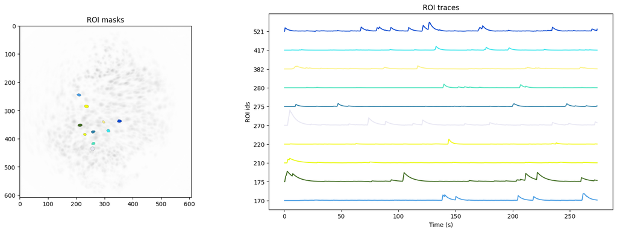

```python
import random
from matplotlib.colors import ListedColormap
import numpy as np
roi_ids = [170, 175, 210, 220, 270, 275, 280, 382, 417, 521]
fig = plt.figure(figsize=(18, 6))
gs = fig.add_gridspec(1, 2, width_ratios=[1, 2], wspace=0.3)
ax1 = fig.add_subplot(gs[0, 1])
ax2 = fig.add_subplot(gs[0, 0])

ax2.imshow(max_projection_image.data[:], cmap="binary", alpha=0.2)

timestamps = roi_response_series.timestamps[:]
for n, roi_id in enumerate(roi_ids):
    random_color = [random.random() for _ in range(3)] + [1]
    custom_cmap = ListedColormap([[0, 0, 0, 0], random_color])

    ax1.plot(timestamps, roi_response_series.data[:,roi_id] + n*np.max(roi_response_series.data[:,:]), color=random_color)

    image_mask = plane_segmentation.image_mask[roi_id]

    ax2.imshow(image_mask, cmap=custom_cmap)

ax1.set_yticks([n*np.max(roi_response_series.data[:,:]) for n in range(len(roi_ids))])
ax1.set_yticklabels(roi_ids)
ax1.set_xlabel("Time (s)")
ax1.set_ylabel("ROI ids")
ax1.set_title("ROI traces")

ax2.set_title("ROI masks")

plt.show()
```

# Access Freezing Behavior

#### **Only for conditioning session** "NeutralExposure", "FC", "Recall1", "Recall2", "Recall3"

This section demonstrates how to access the freeze analysis output and metadata.

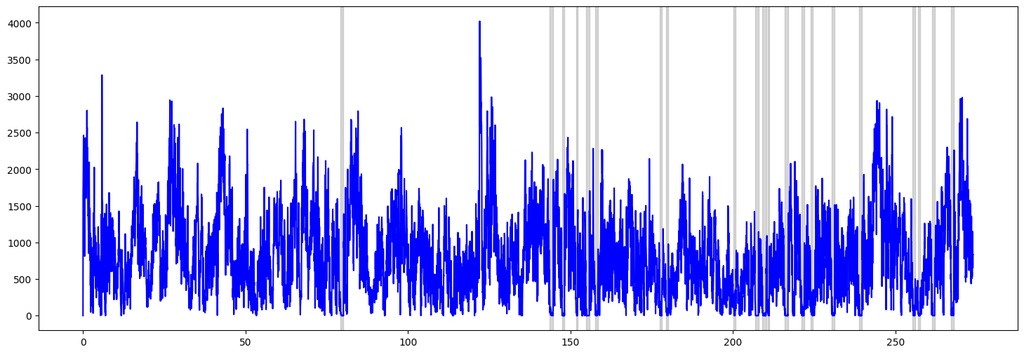

```python
import numpy as np
motion_series = nwbfile.processing["behavior"]["MotionSeries"].data[:]
rate = nwbfile.processing["behavior"]["MotionSeries"].rate
starting_time = nwbfile.processing["behavior"]["MotionSeries"].starting_time
time = np.linspace(starting_time, motion_series.shape[0] / rate, motion_series.shape[0])
start_times = nwbfile.processing["behavior"]["FreezingIntervals"].start_time[:]
stop_times = nwbfile.processing["behavior"]["FreezingIntervals"].stop_time[:]
import matplotlib.pyplot as plt

# Plotting
fig, ax = plt.subplots(figsize=(18, 6))
# Overlay grey boxes for each interval
for start, stop in zip(start_times, stop_times):
    if start > motion_series.shape[0] / rate:
        break
    ax.axvspan(start, stop, color="grey", alpha=0.3)
# Plot the time series
ax.plot(time, motion_series, color="blue", label="Motion Series")
plt.show()
```

# Access Shock Stimulus table

#### **Only for fear conditioning session** "FC"

This section demonstrates how to access the shock stimulus table.

```python
shock_stimulus = nwbfile.stimulus["ShockStimuli"]
shock_stimulus.description
```

```
'During aversive encoding, after a baseline period of 2 min, mice received three 2 s foot shocks of either amplitude 0.25 mA (low-shock) or 1.5 mA (high-shock), with an intershock interval of 1 min. All testing was done in Med Associates chambers. '
```

```python
shock_stimulus.to_dataframe()
```

| id | start_time | stop_time | shock_amplitude |
| --- | --- | --- | --- |
| 0 | 120.0 | 122.0 | 0.25 |
| 1 | 180.0 | 182.0 | 0.25 |
| 2 | 240.0 | 242.0 | 0.25 |

# Access EEG or EMG Signals

#### **Only for offline session** "OfflineDay1Session1", "OfflineDay1Session2", ..., "OfflineDay2Session1", ...

```python
subject_id = "Ca-EEG3-4"
session_id = "OfflineDay1Session1"
```

```python
from dandi.dandiapi import DandiAPIClient

nwbfile_path = f"sub-{subject_id}/sub-{subject_id}_ses-{session_id}_ophys.nwb"

dandiset_id = "000718"
with DandiAPIClient() as client:
    asset = client.get_dandiset(dandiset_id, 'draft').get_asset_by_path(nwbfile_path)
    s3_url = asset.get_content_url(follow_redirects=1, strip_query=False)

import h5py
import remfile
from pynwb import NWBHDF5IO

file = remfile.File(s3_url)
h5_file = h5py.File(file, "r")
io = NWBHDF5IO(file=h5_file, load_namespaces=True)
nwbfile = io.read()
nwbfile.session_description
```

```
'After Neutral Exposure and Fear Conditioning sessions, mice were taken out of the testing chambers and immediately placed in their homecage (scope was not removed).The homecage was placed in a dark grey storage bin with a webcam on top of the bin, taped to a wooden plank, looking down into the home…
```

This section demonstrates how to access the data recorded with the HD-X02 wireless telemetry probe.

### EEG Signal

```python
eeg_signal = nwbfile.acquisition["EEGSignal"]
eeg_signal
```

EEGSignal (TimeSeries)

starting_time: 0.0

rate: 500.0

resolution: -1.0

comments: no comments

description: EEG signal recorder with HD-X02 wireless telemetry probe

conversion: 1.0

offset: 0.0

unit: volts

**data**

HDF5 dataset

| Data type | float32 |
| --- | --- |
| Shape | (300064,) |
| Array size | 1.14 MiB |
| Chunk shape | (300064,) |
| Compression | gzip |
| Compression opts | 4 |
| Uncompressed size (bytes) | 1200256 |
| Compressed size (bytes) | 629623 |
| Compression ratio | 1.9063090134890244 |

starting_time_unit: seconds

In this case since the signal has regular timestamps, the starting time and rate are saved instead of timestamps. To retrieve the timestamps, we simply use the get_timestamps() function

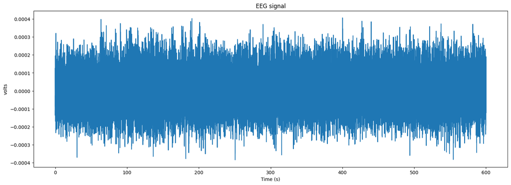

```python
timestamps = eeg_signal.get_timestamps()
fig, ax = plt.subplots(figsize=(18, 6))
ax.plot(timestamps, eeg_signal.data[:])
ax.set_title("EEG signal")
ax.set_xlabel("Time (s)")
ax.set_ylabel(eeg_signal.unit)
plt.show()
```

### EMG Signal

```python
emg_signal = nwbfile.acquisition["EMGSignal"]
emg_signal
```

EMGSignal (TimeSeries)

starting_time: 0.0

rate: 500.0

resolution: -1.0

comments: no comments

description: EMG signal recorder with HD-X02 wireless telemetry probe

conversion: 1.0

offset: 0.0

unit: volts

**data**

HDF5 dataset

| Data type | float32 |
| --- | --- |
| Shape | (300064,) |
| Array size | 1.14 MiB |
| Chunk shape | (300064,) |
| Compression | gzip |
| Compression opts | 4 |
| Uncompressed size (bytes) | 1200256 |
| Compressed size (bytes) | 595913 |
| Compression ratio | 2.014146360290848 |

starting_time_unit: seconds

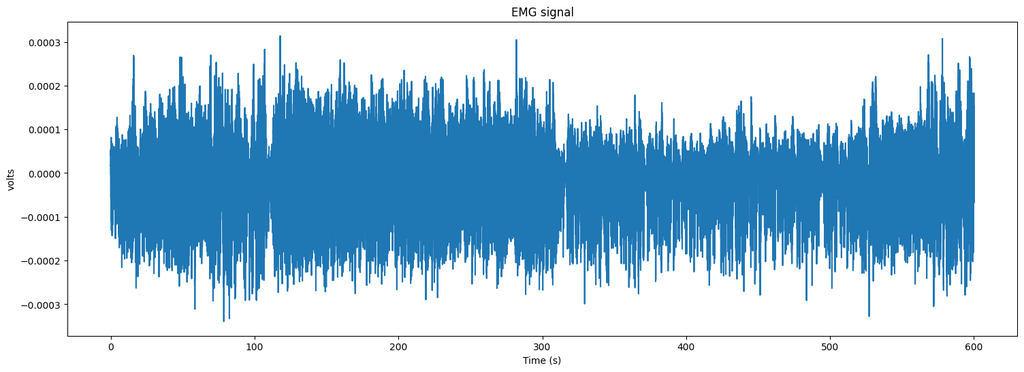

```python
timestamps = emg_signal.get_timestamps()
fig, ax = plt.subplots(figsize=(18, 6))
ax.plot(timestamps, emg_signal.data[:])
ax.set_title("EMG signal")
ax.set_xlabel("Time (s)")
ax.set_ylabel(emg_signal.unit)
plt.show()
```

### Temperature Signal

```python
temperature_signal = nwbfile.acquisition["TemperatureSignal"]
temperature_signal
```

TemperatureSignal (TimeSeries)

starting_time: 0.0

rate: 500.0

resolution: -1.0

comments: no comments

description: Temperature signal recorder with HD-X02 wireless telemetry probe

conversion: 1.0

offset: 0.0

unit: celsius

**data**

HDF5 dataset

| Data type | float32 |
| --- | --- |
| Shape | (300064,) |
| Array size | 1.14 MiB |
| Chunk shape | (300064,) |
| Compression | gzip |
| Compression opts | 4 |
| Uncompressed size (bytes) | 1200256 |
| Compressed size (bytes) | 521839 |
| Compression ratio | 2.3000503986861847 |

starting_time_unit: seconds

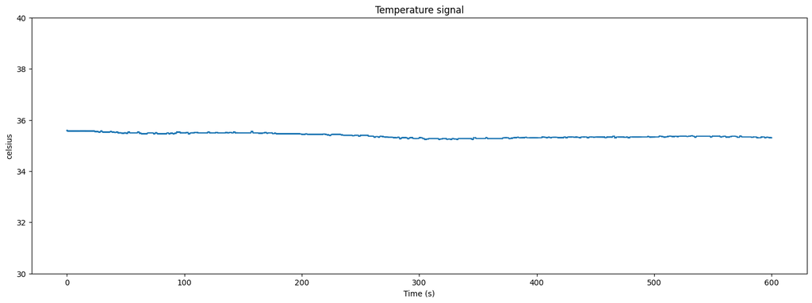

```python
timestamps = temperature_signal.get_timestamps()
fig, ax = plt.subplots(figsize=(18, 6))
ax.plot(timestamps, temperature_signal.data[:])
ax.set_title("Temperature signal")
ax.set_xlabel("Time (s)")
ax.set_ylabel(temperature_signal.unit)
ax.set_ylim(30, 40)
plt.show()
```

### Activity Signal

```python
activity_signal = nwbfile.acquisition["ActivitySignal"]
activity_signal
```

ActivitySignal (TimeSeries)

starting_time: 0.0

rate: 500.0

resolution: -1.0

comments: no comments

description: Activity signal recorder with HD-X02 wireless telemetry probe. It refers to the motion of the probe relative to the receiver and it can be used as a proxy for locomotion.

conversion: 1.0

offset: 0.0

unit: n.a.

**data**

HDF5 dataset

| Data type | float32 |
| --- | --- |
| Shape | (300064,) |
| Array size | 1.14 MiB |
| Chunk shape | (300064,) |
| Compression | gzip |
| Compression opts | 4 |
| Uncompressed size (bytes) | 1200256 |
| Compressed size (bytes) | 1101141 |
| Compression ratio | 1.0900111793130944 |

starting_time_unit: seconds

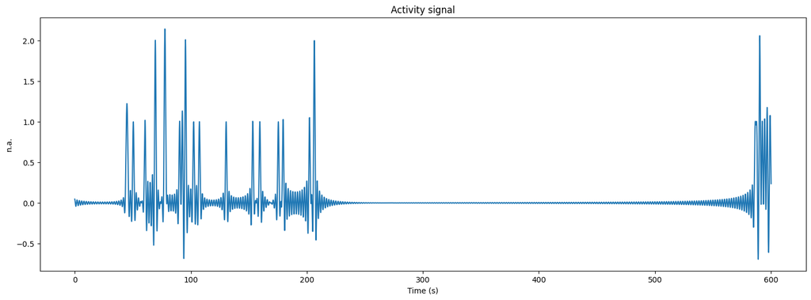

```python
timestamps = activity_signal.get_timestamps()
fig, ax = plt.subplots(figsize=(18, 6))
ax.plot(timestamps, activity_signal.data[:])
ax.set_title("Activity signal")
ax.set_xlabel("Time (s)")
ax.set_ylabel(activity_signal.unit)
plt.show()
```

# Access Sleep Classification

This section demonstrates how to access the sleep classification data.

```python
sleep_intervals = nwbfile.processing["sleep"]["SleepIntervals"].to_dataframe()
sleep_intervals
```

| id | start_time | stop_time | sleep_state |
| --- | --- | --- | --- |
| 0 | 0.000000 | 42.800000 | quiet wake |
| 1 | 42.866667 | 60.800000 | wake |
| 2 | 60.866667 | 66.733333 | quiet wake |
| 3 | 66.800000 | 78.800000 | wake |
| 4 | 78.866667 | 84.733333 | quiet wake |
| 5 | 84.800000 | 108.733333 | wake |
| 6 | 108.800000 | 126.800000 | quiet wake |
| 7 | 126.866667 | 132.733333 | wake |
| 8 | 132.800000 | 150.733333 | quiet wake |
| 9 | 150.800000 | 180.733333 | wake |
| 10 | 180.800000 | 198.733333 | quiet wake |
| 11 | 198.800000 | 210.800000 | wake |
| 12 | 210.866667 | 582.800000 | quiet wake |
| 13 | 582.866667 | 599.266667 | wake |

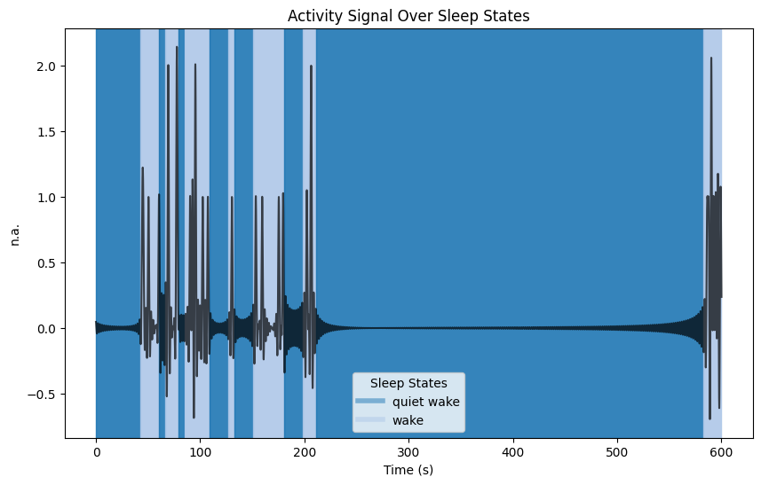

```python
import matplotlib.pyplot as plt

unique_states = sleep_intervals["sleep_state"].unique()
colors = plt.cm.tab20.colors  # Use a color map with enough colors
color_mapping = {state: colors[i % len(colors)] for i, state in enumerate(unique_states)}

# Plotting
fig, ax = plt.subplots(figsize=(10, 6))

# Overlay boxes for each interval with dynamically assigned colors
for start, stop, state in zip(sleep_intervals["start_time"], sleep_intervals["stop_time"], sleep_intervals["sleep_state"]):
    ax.axvspan(start, stop, color=color_mapping[state], alpha=0.9, label=state)

ax.plot(activity_signal.get_timestamps(), activity_signal.data[:], color = "black", alpha=0.7)

ax.set_title("Activity Signal Over Sleep States")
ax.set_xlabel("Time (s)")
ax.set_ylabel(activity_signal.unit)

# Create a legend with unique sleep states
handles = [plt.Line2D([0], [0], color=color_mapping[state], lw=4, alpha=0.5) for state in unique_states]
ax.legend(handles, unique_states, title="Sleep States")
```

# Access Week-long recordings and cross sessions cell registration

```python
subject_id = "Ca-EEG2-1"
session_id = "Week"
```

```python
from dandi.dandiapi import DandiAPIClient

nwbfile_path = f"sub-{subject_id}/sub-{subject_id}_ses-{session_id}.nwb"

dandiset_id = "000718"
with DandiAPIClient() as client:
    asset = client.get_dandiset(dandiset_id, 'draft').get_asset_by_path(nwbfile_path)
    s3_url = asset.get_content_url(follow_redirects=1, strip_query=False)

import h5py
import remfile
from pynwb import NWBHDF5IO

file = remfile.File(s3_url)
h5_file = h5py.File(file, "r")
io = NWBHDF5IO(file=h5_file, load_namespaces=True)
nwbfile = io.read()
nwbfile
```

root (NWBFile)

session_description:

identifier: 26ca7e3f-a838-4603-b0c7-f777cfb83943

**session_start_time**

2021-10-08 07:00:00+00:00

**timestamps_reference_time**

2021-10-08 07:00:00+00:00

**file_create_date**

**0**

2024-12-10 14:05:46.100834+01:00

**experimenter**

('Zaki, Yosif',)

**related_publications**

('https://doi.org/10.1038/s41586-024-08168-4',)

**acquisition**

**ActivitySignal (TimeSeries)**

starting_time: 0.0

rate: 500.0

resolution: -1.0

comments: no comments

description: Activity signal recorder with HD-X02 wireless telemetry probe. It refers to the motion of the probe relative to the receiver and it can be used as a proxy for locomotion.

conversion: 1.0

offset: 0.0

unit: n.a.

**data**

HDF5 dataset

| Data type | float32 |
| --- | --- |
| Shape | (404395000,) |
| Array size | 1.51 GiB |
| Chunk shape | (2500000,) |
| Compression | gzip |
| Compression opts | 4 |
| Uncompressed size (bytes) | 1617580000 |
| Compressed size (bytes) | 1477940351 |
| Compression ratio | 1.0944826013482327 |

starting_time_unit: seconds

**EEGSignal (TimeSeries)**

starting_time: 0.0

rate: 500.0

resolution: -1.0

comments: no comments

description: EEG signal recorder with HD-X02 wireless telemetry probe

conversion: 1.0

offset: 0.0

unit: volts

**data**

HDF5 dataset

| Data type | float32 |
| --- | --- |
| Shape | (404395000,) |
| Array size | 1.51 GiB |
| Chunk shape | (2500000,) |
| Compression | gzip |
| Compression opts | 4 |
| Uncompressed size (bytes) | 1617580000 |
| Compressed size (bytes) | 825297164 |
| Compression ratio | 1.959997041744348 |

starting_time_unit: seconds

**EMGSignal (TimeSeries)**

starting_time: 0.0

rate: 500.0

resolution: -1.0

comments: no comments

description: EMG signal recorder with HD-X02 wireless telemetry probe

conversion: 1.0

offset: 0.0

unit: volts

**data**

HDF5 dataset

| Data type | float32 |
| --- | --- |
| Shape | (404395000,) |
| Array size | 1.51 GiB |
| Chunk shape | (2500000,) |
| Compression | gzip |
| Compression opts | 4 |
| Uncompressed size (bytes) | 1617580000 |
| Compressed size (bytes) | 745747507 |
| Compression ratio | 2.1690719510511216 |

starting_time_unit: seconds

**TemperatureSignal (TimeSeries)**

starting_time: 0.0

rate: 500.0

resolution: -1.0

comments: no comments

description: Temperature signal recorder with HD-X02 wireless telemetry probe

conversion: 1.0

offset: 0.0

unit: celsius

**data**

HDF5 dataset

| Data type | float32 |
| --- | --- |
| Shape | (404395000,) |
| Array size | 1.51 GiB |
| Chunk shape | (2500000,) |
| Compression | gzip |
| Compression opts | 4 |
| Uncompressed size (bytes) | 1617580000 |
| Compressed size (bytes) | 616766636 |
| Compression ratio | 2.622677534068169 |

starting_time_unit: seconds

**keywords**

HDF5 dataset

| Data type | object |
| --- | --- |
| Shape | (8,) |
| Array size | 64.00 bytes |
| Chunk shape | None |
| Compression | None |
| Compression opts | None |
| Uncompressed size (bytes) | 64 |
| Compressed size (bytes) | 128 |
| Compression ratio | 0.5 |

['hippocampus' 'learning' 'memory-linking' 'ensemble' 'reactivation' 'co-activity' 'offline periods' 'aversive']

**processing**

**cell_registration (ProcessingModule)**

description: Processing module for cross session cell registration. Cells recorded across sessions were cross-registered using a previously published open-source cross-registration algorithm, CellReg, using the spatial correlations of nearby cells to determine whether highly correlated footprints close in space are likely to be the same cell across sessions.Each offline recording was cross-registered with all the encoding and recall sessions, but not with the other offline sessions because cross-registering between all sessions would lead to too many conflicts and, therefore, to no cells cross-registered across all sessions.Each table represents the output of the cross-registration between one offline sessions and all the encoding and recall sessions. A table maps the global ROI ids (row of the table) to the ROI ids in each of cross-registered session's plane segmentation.

**OfflineDay2Session10vsConditioningSessions (DynamicTable)**

description: Table maps the global ROI ids (row of the table) to the ROI ids in each of cross-registered session's plane segmentation.The column names refer to the cross-registered session's idsThe values -9999 indicates no correspondence.

**columns**

**Ca_EEG2-1_FC**

ROI indexes of plane segmentation of session Ca_EEG2-1_FC

**Ca_EEG2-1_NeutralExposure**

ROI indexes of plane segmentation of session Ca_EEG2-1_NeutralExposure

**Ca_EEG2-1_OfflineDay2Session10**

ROI indexes of plane segmentation of session Ca_EEG2-1_OfflineDay2Session10

**Ca_EEG2-1_Recall1**

ROI indexes of plane segmentation of session Ca_EEG2-1_Recall1

**table**

| id | Ca_EEG2-1_FC | Ca_EEG2-1_NeutralExposure | Ca_EEG2-1_OfflineDay2Session10 | Ca_EEG2-1_Recall1 |
| --- | --- | --- | --- | --- |
| 0 | 0 | 2 | 3 | -9999 |
| 1 | 1 | 4 | 4 | -9999 |
| 2 | -9999 | -9999 | 5 | -9999 |
| 3 | 3 | -9999 | -9999 | -9999 |

... and 1322 more row(s).

**OfflineDay2Session11vsConditioningSessions (DynamicTable)**

description: Table maps the global ROI ids (row of the table) to the ROI ids in each of cross-registered session's plane segmentation.The column names refer to the cross-registered session's idsThe values -9999 indicates no correspondence.

**columns**

**Ca_EEG2-1_FC**

ROI indexes of plane segmentation of session Ca_EEG2-1_FC

**Ca_EEG2-1_NeutralExposure**

ROI indexes of plane segmentation of session Ca_EEG2-1_NeutralExposure

**Ca_EEG2-1_OfflineDay2Session11**

ROI indexes of plane segmentation of session Ca_EEG2-1_OfflineDay2Session11

**Ca_EEG2-1_Recall1**

ROI indexes of plane segmentation of session Ca_EEG2-1_Recall1

**table**

| id | Ca_EEG2-1_FC | Ca_EEG2-1_NeutralExposure | Ca_EEG2-1_OfflineDay2Session11 | Ca_EEG2-1_Recall1 |
| --- | --- | --- | --- | --- |
| 0 | 0 | 2 | -9999 | -9999 |
| 1 | -9999 | 4 | 3 | -9999 |
| 2 | 2 | -9999 | -9999 | -9999 |
| 3 | 3 | -9999 | -9999 | -9999 |

... and 1488 more row(s).

**OfflineDay2Session12vsConditioningSessions (DynamicTable)**

description: Table maps the global ROI ids (row of the table) to the ROI ids in each of cross-registered session's plane segmentation.The column names refer to the cross-registered session's idsThe values -9999 indicates no correspondence.

**columns**

**Ca_EEG2-1_FC**

ROI indexes of plane segmentation of session Ca_EEG2-1_FC

**Ca_EEG2-1_NeutralExposure**

ROI indexes of plane segmentation of session Ca_EEG2-1_NeutralExposure

**Ca_EEG2-1_OfflineDay2Session12**

ROI indexes of plane segmentation of session Ca_EEG2-1_OfflineDay2Session12

**Ca_EEG2-1_Recall1**

ROI indexes of plane segmentation of session Ca_EEG2-1_Recall1

**table**

| id | Ca_EEG2-1_FC | Ca_EEG2-1_NeutralExposure | Ca_EEG2-1_OfflineDay2Session12 | Ca_EEG2-1_Recall1 |
| --- | --- | --- | --- | --- |
| 0 | 0 | 2 | -9999 | -9999 |
| 1 | -9999 | 4 | -9999 | -9999 |
| 2 | 2 | -9999 | -9999 | -9999 |
| 3 | 3 | -9999 | -9999 | -9999 |

... and 1470 more row(s).

**OfflineDay2Session13vsConditioningSessions (DynamicTable)**

description: Table maps the global ROI ids (row of the table) to the ROI ids in each of cross-registered session's plane segmentation.The column names refer to the cross-registered session's idsThe values -9999 indicates no correspondence.

**columns**

**Ca_EEG2-1_FC**

ROI indexes of plane segmentation of session Ca_EEG2-1_FC

**Ca_EEG2-1_NeutralExposure**

ROI indexes of plane segmentation of session Ca_EEG2-1_NeutralExposure

**Ca_EEG2-1_OfflineDay2Session13**

ROI indexes of plane segmentation of session Ca_EEG2-1_OfflineDay2Session13

**Ca_EEG2-1_Recall1**

ROI indexes of plane segmentation of session Ca_EEG2-1_Recall1

**table**

| id | Ca_EEG2-1_FC | Ca_EEG2-1_NeutralExposure | Ca_EEG2-1_OfflineDay2Session13 | Ca_EEG2-1_Recall1 |
| --- | --- | --- | --- | --- |
| 0 | 0 | 2 | -9999 | -9999 |
| 1 | -9999 | 4 | -9999 | -9999 |
| 2 | 2 | -9999 | -9999 | -9999 |
| 3 | 3 | -9999 | -9999 | -9999 |

... and 1425 more row(s).

**OfflineDay2Session14vsConditioningSessions (DynamicTable)**

description: Table maps the global ROI ids (row of the table) to the ROI ids in each of cross-registered session's plane segmentation.The column names refer to the cross-registered session's idsThe values -9999 indicates no correspondence.

**columns**

**Ca_EEG2-1_FC**

ROI indexes of plane segmentation of session Ca_EEG2-1_FC

**Ca_EEG2-1_NeutralExposure**

ROI indexes of plane segmentation of session Ca_EEG2-1_NeutralExposure

**Ca_EEG2-1_OfflineDay2Session14**

ROI indexes of plane segmentation of session Ca_EEG2-1_OfflineDay2Session14

**Ca_EEG2-1_Recall1**

ROI indexes of plane segmentation of session Ca_EEG2-1_Recall1

**table**

| id | Ca_EEG2-1_FC | Ca_EEG2-1_NeutralExposure | Ca_EEG2-1_OfflineDay2Session14 | Ca_EEG2-1_Recall1 |
| --- | --- | --- | --- | --- |
| 0 | 0 | 2 | -9999 | -9999 |
| 1 | -9999 | 4 | -9999 | -9999 |
| 2 | 2 | -9999 | 4 | -9999 |
| 3 | 3 | -9999 | -9999 | -9999 |

... and 1407 more row(s).

**OfflineDay2Session15vsConditioningSessions (DynamicTable)**

description: Table maps the global ROI ids (row of the table) to the ROI ids in each of cross-registered session's plane segmentation.The column names refer to the cross-registered session's idsThe values -9999 indicates no correspondence.

**columns**

**Ca_EEG2-1_FC**

ROI indexes of plane segmentation of session Ca_EEG2-1_FC

**Ca_EEG2-1_NeutralExposure**

ROI indexes of plane segmentation of session Ca_EEG2-1_NeutralExposure

**Ca_EEG2-1_OfflineDay2Session15**

ROI indexes of plane segmentation of session Ca_EEG2-1_OfflineDay2Session15

**Ca_EEG2-1_Recall1**

ROI indexes of plane segmentation of session Ca_EEG2-1_Recall1

**table**

| id | Ca_EEG2-1_FC | Ca_EEG2-1_NeutralExposure | Ca_EEG2-1_OfflineDay2Session15 | Ca_EEG2-1_Recall1 |
| --- | --- | --- | --- | --- |
| 0 | 0 | 2 | 0 | -9999 |
| 1 | -9999 | 4 | -9999 | -9999 |
| 2 | 2 | -9999 | -9999 | -9999 |
| 3 | 3 | -9999 | -9999 | -9999 |

... and 1409 more row(s).

**OfflineDay2Session16vsConditioningSessions (DynamicTable)**

description: Table maps the global ROI ids (row of the table) to the ROI ids in each of cross-registered session's plane segmentation.The column names refer to the cross-registered session's idsThe values -9999 indicates no correspondence.

**columns**

**Ca_EEG2-1_FC**

ROI indexes of plane segmentation of session Ca_EEG2-1_FC

**Ca_EEG2-1_NeutralExposure**

ROI indexes of plane segmentation of session Ca_EEG2-1_NeutralExposure

**Ca_EEG2-1_OfflineDay2Session16**

ROI indexes of plane segmentation of session Ca_EEG2-1_OfflineDay2Session16

**Ca_EEG2-1_Recall1**

ROI indexes of plane segmentation of session Ca_EEG2-1_Recall1

**table**

| id | Ca_EEG2-1_FC | Ca_EEG2-1_NeutralExposure | Ca_EEG2-1_OfflineDay2Session16 | Ca_EEG2-1_Recall1 |
| --- | --- | --- | --- | --- |
| 0 | 0 | 2 | -9999 | -9999 |
| 1 | -9999 | 4 | -9999 | -9999 |
| 2 | 2 | -9999 | -9999 | -9999 |
| 3 | 3 | -9999 | -9999 | -9999 |

... and 1441 more row(s).

**OfflineDay2Session17vsConditioningSessions (DynamicTable)**

description: Table maps the global ROI ids (row of the table) to the ROI ids in each of cross-registered session's plane segmentation.The column names refer to the cross-registered session's idsThe values -9999 indicates no correspondence.

**columns**

**Ca_EEG2-1_FC**

ROI indexes of plane segmentation of session Ca_EEG2-1_FC

**Ca_EEG2-1_NeutralExposure**

ROI indexes of plane segmentation of session Ca_EEG2-1_NeutralExposure

**Ca_EEG2-1_OfflineDay2Session17**

ROI indexes of plane segmentation of session Ca_EEG2-1_OfflineDay2Session17

**Ca_EEG2-1_Recall1**

ROI indexes of plane segmentation of session Ca_EEG2-1_Recall1

**table**

| id | Ca_EEG2-1_FC | Ca_EEG2-1_NeutralExposure | Ca_EEG2-1_OfflineDay2Session17 | Ca_EEG2-1_Recall1 |
| --- | --- | --- | --- | --- |
| 0 | 0 | 2 | -9999 | -9999 |
| 1 | -9999 | 4 | 1 | -9999 |
| 2 | 2 | -9999 | -9999 | -9999 |
| 3 | 3 | -9999 | -9999 | -9999 |

... and 1402 more row(s).

**OfflineDay2Session18vsConditioningSessions (DynamicTable)**

description: Table maps the global ROI ids (row of the table) to the ROI ids in each of cross-registered session's plane segmentation.The column names refer to the cross-registered session's idsThe values -9999 indicates no correspondence.

**columns**

**Ca_EEG2-1_FC**

ROI indexes of plane segmentation of session Ca_EEG2-1_FC

**Ca_EEG2-1_NeutralExposure**

ROI indexes of plane segmentation of session Ca_EEG2-1_NeutralExposure

**Ca_EEG2-1_OfflineDay2Session18**

ROI indexes of plane segmentation of session Ca_EEG2-1_OfflineDay2Session18

**Ca_EEG2-1_Recall1**

ROI indexes of plane segmentation of session Ca_EEG2-1_Recall1

**table**

| id | Ca_EEG2-1_FC | Ca_EEG2-1_NeutralExposure | Ca_EEG2-1_OfflineDay2Session18 | Ca_EEG2-1_Recall1 |
| --- | --- | --- | --- | --- |
| 0 | 0 | 2 | -9999 | -9999 |
| 1 | -9999 | 4 | -9999 | -9999 |
| 2 | 2 | -9999 | -9999 | -9999 |
| 3 | 3 | -9999 | -9999 | -9999 |

... and 1329 more row(s).

**OfflineDay2Session19vsConditioningSessions (DynamicTable)**

description: Table maps the global ROI ids (row of the table) to the ROI ids in each of cross-registered session's plane segmentation.The column names refer to the cross-registered session's idsThe values -9999 indicates no correspondence.

**columns**

**Ca_EEG2-1_FC**

ROI indexes of plane segmentation of session Ca_EEG2-1_FC

**Ca_EEG2-1_NeutralExposure**

ROI indexes of plane segmentation of session Ca_EEG2-1_NeutralExposure

**Ca_EEG2-1_OfflineDay2Session19**

ROI indexes of plane segmentation of session Ca_EEG2-1_OfflineDay2Session19

**Ca_EEG2-1_Recall1**

ROI indexes of plane segmentation of session Ca_EEG2-1_Recall1

**table**

| id | Ca_EEG2-1_FC | Ca_EEG2-1_NeutralExposure | Ca_EEG2-1_OfflineDay2Session19 | Ca_EEG2-1_Recall1 |
| --- | --- | --- | --- | --- |
| 0 | 0 | 2 | -9999 | -9999 |
| 1 | -9999 | 4 | -9999 | -9999 |
| 2 | 2 | -9999 | -9999 | -9999 |
| 3 | 3 | -9999 | -9999 | -9999 |

... and 1346 more row(s).

**OfflineDay2Session1vsConditioningSessions (DynamicTable)**

description: Table maps the global ROI ids (row of the table) to the ROI ids in each of cross-registered session's plane segmentation.The column names refer to the cross-registered session's idsThe values -9999 indicates no correspondence.

**columns**

**Ca_EEG2-1_FC**

ROI indexes of plane segmentation of session Ca_EEG2-1_FC

**Ca_EEG2-1_NeutralExposure**

ROI indexes of plane segmentation of session Ca_EEG2-1_NeutralExposure

**Ca_EEG2-1_OfflineDay2Session1**

ROI indexes of plane segmentation of session Ca_EEG2-1_OfflineDay2Session1

**Ca_EEG2-1_Recall1**

ROI indexes of plane segmentation of session Ca_EEG2-1_Recall1

**table**

| id | Ca_EEG2-1_FC | Ca_EEG2-1_NeutralExposure | Ca_EEG2-1_OfflineDay2Session1 | Ca_EEG2-1_Recall1 |
| --- | --- | --- | --- | --- |
| 0 | 0 | 2 | 2 | -9999 |
| 1 | -9999 | -9999 | 4 | -9999 |
| 2 | 2 | -9999 | -9999 | -9999 |
| 3 | 3 | -9999 | -9999 | -9999 |

... and 1391 more row(s).

**OfflineDay2Session2vsConditioningSessions (DynamicTable)**

description: Table maps the global ROI ids (row of the table) to the ROI ids in each of cross-registered session's plane segmentation.The column names refer to the cross-registered session's idsThe values -9999 indicates no correspondence.

**columns**

**Ca_EEG2-1_FC**

ROI indexes of plane segmentation of session Ca_EEG2-1_FC

**Ca_EEG2-1_NeutralExposure**

ROI indexes of plane segmentation of session Ca_EEG2-1_NeutralExposure

**Ca_EEG2-1_OfflineDay2Session2**

ROI indexes of plane segmentation of session Ca_EEG2-1_OfflineDay2Session2

**Ca_EEG2-1_Recall1**

ROI indexes of plane segmentation of session Ca_EEG2-1_Recall1

**table**

| id | Ca_EEG2-1_FC | Ca_EEG2-1_NeutralExposure | Ca_EEG2-1_OfflineDay2Session2 | Ca_EEG2-1_Recall1 |
| --- | --- | --- | --- | --- |
| 0 | 0 | 2 | -9999 | -9999 |
| 1 | -9999 | -9999 | 0 | -9999 |
| 2 | 2 | -9999 | -9999 | -9999 |
| 3 | 3 | -9999 | -9999 | -9999 |

... and 1485 more row(s).

**OfflineDay2Session3vsConditioningSessions (DynamicTable)**

description: Table maps the global ROI ids (row of the table) to the ROI ids in each of cross-registered session's plane segmentation.The column names refer to the cross-registered session's idsThe values -9999 indicates no correspondence.

**columns**

**Ca_EEG2-1_FC**

ROI indexes of plane segmentation of session Ca_EEG2-1_FC

**Ca_EEG2-1_NeutralExposure**

ROI indexes of plane segmentation of session Ca_EEG2-1_NeutralExposure

**Ca_EEG2-1_OfflineDay2Session3**

ROI indexes of plane segmentation of session Ca_EEG2-1_OfflineDay2Session3

**Ca_EEG2-1_Recall1**

ROI indexes of plane segmentation of session Ca_EEG2-1_Recall1

**table**

| id | Ca_EEG2-1_FC | Ca_EEG2-1_NeutralExposure | Ca_EEG2-1_OfflineDay2Session3 | Ca_EEG2-1_Recall1 |
| --- | --- | --- | --- | --- |
| 0 | 0 | 2 | -9999 | -9999 |
| 1 | -9999 | 4 | -9999 | -9999 |
| 2 | 2 | -9999 | -9999 | -9999 |
| 3 | 3 | -9999 | -9999 | -9999 |

... and 1422 more row(s).

**OfflineDay2Session4vsConditioningSessions (DynamicTable)**

description: Table maps the global ROI ids (row of the table) to the ROI ids in each of cross-registered session's plane segmentation.The column names refer to the cross-registered session's idsThe values -9999 indicates no correspondence.

**columns**

**Ca_EEG2-1_FC**

ROI indexes of plane segmentation of session Ca_EEG2-1_FC

**Ca_EEG2-1_NeutralExposure**

ROI indexes of plane segmentation of session Ca_EEG2-1_NeutralExposure

**Ca_EEG2-1_OfflineDay2Session4**

ROI indexes of plane segmentation of session Ca_EEG2-1_OfflineDay2Session4

**Ca_EEG2-1_Recall1**

ROI indexes of plane segmentation of session Ca_EEG2-1_Recall1

**table**

| id | Ca_EEG2-1_FC | Ca_EEG2-1_NeutralExposure | Ca_EEG2-1_OfflineDay2Session4 | Ca_EEG2-1_Recall1 |
| --- | --- | --- | --- | --- |
| 0 | 0 | 2 | 3 | -9999 |
| 1 | -9999 | 4 | -9999 | -9999 |
| 2 | 2 | -9999 | -9999 | -9999 |
| 3 | 3 | -9999 | -9999 | -9999 |

... and 1390 more row(s).

**OfflineDay2Session5vsConditioningSessions (DynamicTable)**

description: Table maps the global ROI ids (row of the table) to the ROI ids in each of cross-registered session's plane segmentation.The column names refer to the cross-registered session's idsThe values -9999 indicates no correspondence.

**columns**

**Ca_EEG2-1_FC**

ROI indexes of plane segmentation of session Ca_EEG2-1_FC

**Ca_EEG2-1_NeutralExposure**

ROI indexes of plane segmentation of session Ca_EEG2-1_NeutralExposure

**Ca_EEG2-1_OfflineDay2Session5**

ROI indexes of plane segmentation of session Ca_EEG2-1_OfflineDay2Session5

**Ca_EEG2-1_Recall1**

ROI indexes of plane segmentation of session Ca_EEG2-1_Recall1

**table**

| id | Ca_EEG2-1_FC | Ca_EEG2-1_NeutralExposure | Ca_EEG2-1_OfflineDay2Session5 | Ca_EEG2-1_Recall1 |
| --- | --- | --- | --- | --- |
| 0 | 0 | 2 | -9999 | -9999 |
| 1 | -9999 | -9999 | 2 | -9999 |
| 2 | 2 | -9999 | -9999 | -9999 |
| 3 | 3 | -9999 | -9999 | -9999 |

... and 1473 more row(s).

**OfflineDay2Session6vsConditioningSessions (DynamicTable)**

description: Table maps the global ROI ids (row of the table) to the ROI ids in each of cross-registered session's plane segmentation.The column names refer to the cross-registered session's idsThe values -9999 indicates no correspondence.

**columns**

**Ca_EEG2-1_FC**

ROI indexes of plane segmentation of session Ca_EEG2-1_FC

**Ca_EEG2-1_NeutralExposure**

ROI indexes of plane segmentation of session Ca_EEG2-1_NeutralExposure

**Ca_EEG2-1_OfflineDay2Session6**

ROI indexes of plane segmentation of session Ca_EEG2-1_OfflineDay2Session6

**Ca_EEG2-1_Recall1**

ROI indexes of plane segmentation of session Ca_EEG2-1_Recall1

**table**

| id | Ca_EEG2-1_FC | Ca_EEG2-1_NeutralExposure | Ca_EEG2-1_OfflineDay2Session6 | Ca_EEG2-1_Recall1 |
| --- | --- | --- | --- | --- |
| 0 | 0 | 2 | -9999 | -9999 |
| 1 | -9999 | 4 | -9999 | -9999 |
| 2 | 2 | -9999 | -9999 | -9999 |
| 3 | 3 | -9999 | -9999 | -9999 |

... and 1505 more row(s).

**OfflineDay2Session7vsConditioningSessions (DynamicTable)**

description: Table maps the global ROI ids (row of the table) to the ROI ids in each of cross-registered session's plane segmentation.The column names refer to the cross-registered session's idsThe values -9999 indicates no correspondence.

**columns**

**Ca_EEG2-1_FC**

ROI indexes of plane segmentation of session Ca_EEG2-1_FC

**Ca_EEG2-1_NeutralExposure**

ROI indexes of plane segmentation of session Ca_EEG2-1_NeutralExposure

**Ca_EEG2-1_OfflineDay2Session7**

ROI indexes of plane segmentation of session Ca_EEG2-1_OfflineDay2Session7

**Ca_EEG2-1_Recall1**

ROI indexes of plane segmentation of session Ca_EEG2-1_Recall1

**table**

| id | Ca_EEG2-1_FC | Ca_EEG2-1_NeutralExposure | Ca_EEG2-1_OfflineDay2Session7 | Ca_EEG2-1_Recall1 |
| --- | --- | --- | --- | --- |
| 0 | 0 | 2 | -9999 | -9999 |
| 1 | -9999 | 4 | -9999 | -9999 |
| 2 | 2 | -9999 | -9999 | -9999 |
| 3 | 3 | -9999 | -9999 | -9999 |

... and 1433 more row(s).

**OfflineDay2Session8vsConditioningSessions (DynamicTable)**

description: Table maps the global ROI ids (row of the table) to the ROI ids in each of cross-registered session's plane segmentation.The column names refer to the cross-registered session's idsThe values -9999 indicates no correspondence.

**columns**

**Ca_EEG2-1_FC**

ROI indexes of plane segmentation of session Ca_EEG2-1_FC

**Ca_EEG2-1_NeutralExposure**

ROI indexes of plane segmentation of session Ca_EEG2-1_NeutralExposure

**Ca_EEG2-1_OfflineDay2Session8**

ROI indexes of plane segmentation of session Ca_EEG2-1_OfflineDay2Session8

**Ca_EEG2-1_Recall1**

ROI indexes of plane segmentation of session Ca_EEG2-1_Recall1

**table**

| id | Ca_EEG2-1_FC | Ca_EEG2-1_NeutralExposure | Ca_EEG2-1_OfflineDay2Session8 | Ca_EEG2-1_Recall1 |
| --- | --- | --- | --- | --- |
| 0 | 0 | 2 | -9999 | -9999 |
| 1 | -9999 | 4 | -9999 | -9999 |
| 2 | 2 | -9999 | -9999 | -9999 |
| 3 | 3 | -9999 | -9999 | -9999 |

... and 1429 more row(s).

**OfflineDay2Session9vsConditioningSessions (DynamicTable)**

description: Table maps the global ROI ids (row of the table) to the ROI ids in each of cross-registered session's plane segmentation.The column names refer to the cross-registered session's idsThe values -9999 indicates no correspondence.

**columns**

**Ca_EEG2-1_FC**

ROI indexes of plane segmentation of session Ca_EEG2-1_FC

**Ca_EEG2-1_NeutralExposure**

ROI indexes of plane segmentation of session Ca_EEG2-1_NeutralExposure

**Ca_EEG2-1_OfflineDay2Session9**

ROI indexes of plane segmentation of session Ca_EEG2-1_OfflineDay2Session9

**Ca_EEG2-1_Recall1**

ROI indexes of plane segmentation of session Ca_EEG2-1_Recall1

**table**

| id | Ca_EEG2-1_FC | Ca_EEG2-1_NeutralExposure | Ca_EEG2-1_OfflineDay2Session9 | Ca_EEG2-1_Recall1 |
| --- | --- | --- | --- | --- |
| 0 | 0 | 2 | -9999 | -9999 |
| 1 | -9999 | 4 | 2 | -9999 |
| 2 | 2 | -9999 | -9999 | -9999 |
| 3 | 3 | -9999 | -9999 | -9999 |

... and 1533 more row(s).

**devices**

**HD-X02, Data Science International (Device)**

description: Wireless telemetry probe used to record EEG, EMG, temperature, and activity data

**intervals**

**epochs (TimeIntervals)**

description: experimental epochs

**columns**

**start_time**

Start time of epoch, in seconds

**stop_time**

Stop time of epoch, in seconds

**session_ids**

ID of the session

**table**

| id | start_time | stop_time | session_ids |
| --- | --- | --- | --- |
| 0 | 359058.744 | 359658.717 | NeutralExposure |
| 1 | 617599.999 | 617899.952 | Recall1 |
| 2 | 529884.777 | 530158.743 | FC |
| 3 | 527067.677 | 527667.538 | OfflineDay2Session1 |

... and 23 more row(s).

**subject (Subject)**

age: P12W/P18W

age__reference: birth

description: Adult C57BL/6J wild-type mice from Jackson Laboratories were used. Mice ordered from Jackson arrived group-housed in cages of 4 mice/cage and were singly housed for the experiment. Mice were ordered to arrive at 8-9 weeks of age and underwent behavioral testing about 4-6 weeks after the arrival date. All experimental procedures were approved by the Icahn School of Medicine at Mount Sinai's IACUC.

genotype: wild-type

sex: M

species: Mus musculus

subject_id: Ca_EEG2-1

strain: C57BL/6J

**epochs (TimeIntervals)**

description: experimental epochs

**columns**

**start_time**

Start time of epoch, in seconds

**stop_time**

Stop time of epoch, in seconds

**session_ids**

ID of the session

**table**

| id | start_time | stop_time | session_ids |
| --- | --- | --- | --- |
| 0 | 359058.744 | 359658.717 | NeutralExposure |
| 1 | 617599.999 | 617899.952 | Recall1 |
| 2 | 529884.777 | 530158.743 | FC |
| 3 | 527067.677 | 527667.538 | OfflineDay2Session1 |

... and 23 more row(s).

experiment_description: Simultaneous calcium imaging with Miniscopes and EEG/EMG experiment during retrospective memory-linking behavioral paradigm, to test whether ensemble co-reactivation is sleep-state specific. Mice were exposed to the neutral context for 10 min to explore. During aversive encoding, after a baseline period of 2 min, mice received three 2 s foot shocks of either amplitude 0.25 mA (low-shock) or 1.5 mA (high-shock), with an intershock interval of 1 min. Then, 30 s after the final shock, the mice were removed and returned to the vivarium. On the next 3 days, the mice were tested in the previously experienced aversive and neutral contexts, as well as a completely novel context that they had not been exposed to previously, for 5 min each. The features of the neutral and novel contexts were counter-balanced and were made up of different olfactory, auditory, lighting and tactile cues. The aversive context was always the same with distinct cues from the neutral and novel contexts. In the low- versus high-shock experiments mice were tested in the aversive context first, followed by testing in the neutral and novel context counter-balanced; half of the mice received neutral recall and then novel-context exposure the next day, and the other half received novel-context exposure and then neutral recall.

session_id: Week

lab: Cai

institution: Icahn School of Medicine at Mount Sinai

source_script: Created using NeuroConv v0.6.6

source_script_file_name: C:\Users\Utente\CatalystNeuro\neuroconv\src\neuroconv\basedatainterface.py

surgery: Mice were anaesthetized with 1 to 2% isoflurane for surgical procedures and placed into a stereotaxic frame (David Kopf Instruments). Eye ointment was applied to prevent desiccation, and the mice were kept on a heated pad to prevent hypothermia. Surgery was performed using aseptic technique. After surgery, carprofen (5mg per kg) was administered every day for the following 3 days, and ampicillin (20mg per kg) was administered every day for the next 7days. For calcium imaging experiments with EEG/EMG implants, mice underwent three serial procedures spaced around 2 weeks apart. During the first surgery, mice had 300 nl of AAV1-Syn-GCaMP6f injected into dorsal CA1 (AP, âˆ’2 mm; ML, +1.5 mm; DV, âˆ’1.2 mm), the incision was sutured after the surgery. Then, 2 weeks later during a second surgery, mice had their overlying cortex aspirated and a GRIN lens was implanted above the injection site. This involved aspirating the cortex with a 27-gauge blunt syringe needle attached to a vacuum pump, constantly irrigating with cortex buffer. When the striations of the corpus callosum were visible, a 30-gauge needle replaced the 27-gauge needle for finer-tuned aspiration. Once most of corpus callosum was removed, bleeding was controlled using surgical foam (Surgifoam), and a 1 mm diameter x 4 mm length GRIN lens (GRINTECH) was slowly lowered into the craniotomy. The lens was fixed with cyanoacrylate, and dental acrylic was applied to cement the implant in place and cover the exposed skull. The top of the exposed lens was covered with Kwik-Sil (World Precision Instruments) and then dental cement. During this same surgery, a wireless telemetry probe (HD-X02, Data Science International) was implanted with EEG and EMG wires. Two EMG wires were placed into the left trapezius muscle. One EEG wire was implanted between the skull and dura mater above the dorsal hippocampus on the contralateral hemisphere to the GRIN lens (left hemisphere; AP, âˆ’2 mm; ML, âˆ’1.5 mm), and a reference EEG wire was implanted between the skull and the dura on the right hemisphere overlying the prefrontal cortex (AP, +1.75 mm; ML, âˆ’0.5 mm). Cyanoacrylate and dental cement fixed the GRIN lens, anchor screw, and EEG wires in place. The telemetry probes were implanted during this second surgery to minimize the time mice needed to live with the implant. During the third procedure, the mice were returned to implant the baseplate. The Miniscope with an attached baseplate was lowered near the implanted lens, with the field of view monitored in real-time on a computer. The Miniscope was rotated until a well-exposed field of view was observed, at which point the baseplate was fixed to the implant with cyanoacrylate and dental cement.

virus: AAV1-Syn-GCaMP6f was injected into dorsal CA1 of the hippocampus on the right hemisphere (AP, âˆ’2 mm; ML, +1.5 mm; DV, âˆ’1.2 mm)

```python
nwbfile.session_description
```

```
''
```

```python
from datetime import timedelta

eeg_signal = nwbfile.acquisition["EEGSignal"]
n_samples = eeg_signal.data.shape[0]

# EEGSignal has a fixed sampling rate rather than stored timestamps, so the
# session length is arithmetic. get_timestamps() would build a
# 400-million-element array (several GB) just to read its last value.
# (pynwb >= 4 also offers eeg_signal.get_starting_time() and
# eeg_signal.get_duration() for this.)
duration_s = eeg_signal.starting_time + (n_samples - 1) / eeg_signal.rate

week_session_start = nwbfile.session_start_time
week_session_end = week_session_start + timedelta(seconds=duration_s)
week_session_start = week_session_start.strftime("%Y-%m-%d %H:%M:%S %Z")
week_session_end = week_session_end.strftime("%Y-%m-%d %H:%M:%S %Z")
print(f"Session started:\t{week_session_start} \nSession ended:\t\t{week_session_end}")
```

```
Session started:	2021-10-08 07:00:00 UTC
Session ended:		2021-10-17 15:39:49 UTC
```

## EEG recording

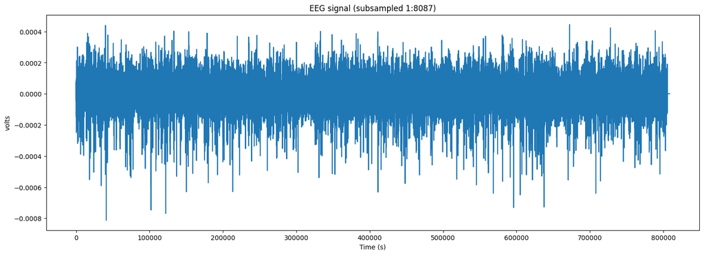

```python
eeg_signal = nwbfile.acquisition["EEGSignal"]

# This recording spans roughly a week at the EEG sample rate, so loading and
# plotting `eeg_signal.data[:]` is hundreds of millions of points — too large
# for matplotlib (and too slow over remfile streaming). Subsample to ~50k
# points for the overview plot; users who want full-resolution data can slice
# `eeg_signal.data[start:stop]` directly.
n = eeg_signal.data.shape[0]
stride = max(1, n // 50_000)
ts_view = eeg_signal.starting_time + np.arange(0, n, stride) / eeg_signal.rate
data_view = eeg_signal.data[::stride]

fig, ax = plt.subplots(figsize=(18, 6))
ax.plot(ts_view, data_view)
ax.set_title(f"EEG signal (subsampled 1:{stride})")
ax.set_xlabel("Time (s)")
ax.set_ylabel(eeg_signal.unit)
plt.show()
```

## Experimental Sessions during the week

```python
nwbfile.epochs.to_dataframe()
```

| id | start_time | stop_time | session_ids |
| --- | --- | --- | --- |
| 0 | 359058.744 | 359658.717 | NeutralExposure |
| 1 | 617599.999 | 617899.952 | Recall1 |
| 2 | 529884.777 | 530158.743 | FC |
| 3 | 527067.677 | 527667.538 | OfflineDay2Session1 |
| 4 | 528867.463 | 529467.359 | OfflineDay2Session2 |
| 5 | 530667.282 | 531267.178 | OfflineDay2Session3 |
| 6 | 532467.102 | 533066.997 | OfflineDay2Session4 |
| 7 | 534266.922 | 534866.817 | OfflineDay2Session5 |
| 8 | 536066.738 | 536666.632 | OfflineDay2Session6 |
| 9 | 537866.553 | 538466.447 | OfflineDay2Session7 |
| 10 | 539666.372 | 540266.265 | OfflineDay2Session8 |
| 11 | 541466.187 | 542066.080 | OfflineDay2Session9 |
| 12 | 543266.005 | 543865.900 | OfflineDay2Session10 |
| 13 | 545065.825 | 545665.720 | OfflineDay2Session11 |
| 14 | 546865.644 | 547465.538 | OfflineDay2Session12 |
| 15 | 548665.430 | 549265.358 | OfflineDay2Session13 |
| 16 | 550465.248 | 551065.177 | OfflineDay2Session14 |
| 17 | 552265.067 | 552864.995 | OfflineDay2Session15 |
| 18 | 554064.885 | 554664.780 | OfflineDay2Session16 |
| 19 | 555864.703 | 556464.597 | OfflineDay2Session17 |
| 20 | 557664.522 | 558264.416 | OfflineDay2Session18 |
| 21 | 559464.340 | 560064.236 | OfflineDay2Session19 |
| 22 | 356757.595 | 356813.764 | OfflineDay1Session1 |
| 23 | 356897.828 | 357005.289 | OfflineDay1Session2 |
| 24 | 357044.154 | 357312.538 | OfflineDay1Session3 |
| 25 | 357350.761 | 357417.826 | OfflineDay1Session4 |
| 26 | 364070.226 | 364370.844 | OfflineDay1Session5 |

## Cell Registration across sessions

```python
nwbfile.processing["cell_registration"]
```

cell_registration (ProcessingModule)

description: Processing module for cross session cell registration. Cells recorded across sessions were cross-registered using a previously published open-source cross-registration algorithm, CellReg, using the spatial correlations of nearby cells to determine whether highly correlated footprints close in space are likely to be the same cell across sessions.Each offline recording was cross-registered with all the encoding and recall sessions, but not with the other offline sessions because cross-registering between all sessions would lead to too many conflicts and, therefore, to no cells cross-registered across all sessions.Each table represents the output of the cross-registration between one offline sessions and all the encoding and recall sessions. A table maps the global ROI ids (row of the table) to the ROI ids in each of cross-registered session's plane segmentation.

**OfflineDay2Session10vsConditioningSessions (DynamicTable)**

description: Table maps the global ROI ids (row of the table) to the ROI ids in each of cross-registered session's plane segmentation.The column names refer to the cross-registered session's idsThe values -9999 indicates no correspondence.

**columns**

**Ca_EEG2-1_FC**

ROI indexes of plane segmentation of session Ca_EEG2-1_FC

**Ca_EEG2-1_NeutralExposure**

ROI indexes of plane segmentation of session Ca_EEG2-1_NeutralExposure

**Ca_EEG2-1_OfflineDay2Session10**

ROI indexes of plane segmentation of session Ca_EEG2-1_OfflineDay2Session10

**Ca_EEG2-1_Recall1**

ROI indexes of plane segmentation of session Ca_EEG2-1_Recall1

**table**

| id | Ca_EEG2-1_FC | Ca_EEG2-1_NeutralExposure | Ca_EEG2-1_OfflineDay2Session10 | Ca_EEG2-1_Recall1 |
| --- | --- | --- | --- | --- |
| 0 | 0 | 2 | 3 | -9999 |
| 1 | 1 | 4 | 4 | -9999 |
| 2 | -9999 | -9999 | 5 | -9999 |
| 3 | 3 | -9999 | -9999 | -9999 |

... and 1322 more row(s).

**OfflineDay2Session11vsConditioningSessions (DynamicTable)**

description: Table maps the global ROI ids (row of the table) to the ROI ids in each of cross-registered session's plane segmentation.The column names refer to the cross-registered session's idsThe values -9999 indicates no correspondence.

**columns**

**Ca_EEG2-1_FC**

ROI indexes of plane segmentation of session Ca_EEG2-1_FC

**Ca_EEG2-1_NeutralExposure**

ROI indexes of plane segmentation of session Ca_EEG2-1_NeutralExposure

**Ca_EEG2-1_OfflineDay2Session11**

ROI indexes of plane segmentation of session Ca_EEG2-1_OfflineDay2Session11

**Ca_EEG2-1_Recall1**

ROI indexes of plane segmentation of session Ca_EEG2-1_Recall1

**table**

| id | Ca_EEG2-1_FC | Ca_EEG2-1_NeutralExposure | Ca_EEG2-1_OfflineDay2Session11 | Ca_EEG2-1_Recall1 |
| --- | --- | --- | --- | --- |
| 0 | 0 | 2 | -9999 | -9999 |
| 1 | -9999 | 4 | 3 | -9999 |
| 2 | 2 | -9999 | -9999 | -9999 |
| 3 | 3 | -9999 | -9999 | -9999 |

... and 1488 more row(s).

**OfflineDay2Session12vsConditioningSessions (DynamicTable)**

description: Table maps the global ROI ids (row of the table) to the ROI ids in each of cross-registered session's plane segmentation.The column names refer to the cross-registered session's idsThe values -9999 indicates no correspondence.

**columns**

**Ca_EEG2-1_FC**

ROI indexes of plane segmentation of session Ca_EEG2-1_FC

**Ca_EEG2-1_NeutralExposure**

ROI indexes of plane segmentation of session Ca_EEG2-1_NeutralExposure

**Ca_EEG2-1_OfflineDay2Session12**

ROI indexes of plane segmentation of session Ca_EEG2-1_OfflineDay2Session12

**Ca_EEG2-1_Recall1**

ROI indexes of plane segmentation of session Ca_EEG2-1_Recall1

**table**

| id | Ca_EEG2-1_FC | Ca_EEG2-1_NeutralExposure | Ca_EEG2-1_OfflineDay2Session12 | Ca_EEG2-1_Recall1 |
| --- | --- | --- | --- | --- |
| 0 | 0 | 2 | -9999 | -9999 |
| 1 | -9999 | 4 | -9999 | -9999 |
| 2 | 2 | -9999 | -9999 | -9999 |
| 3 | 3 | -9999 | -9999 | -9999 |

... and 1470 more row(s).

**OfflineDay2Session13vsConditioningSessions (DynamicTable)**

description: Table maps the global ROI ids (row of the table) to the ROI ids in each of cross-registered session's plane segmentation.The column names refer to the cross-registered session's idsThe values -9999 indicates no correspondence.

**columns**

**Ca_EEG2-1_FC**

ROI indexes of plane segmentation of session Ca_EEG2-1_FC

**Ca_EEG2-1_NeutralExposure**

ROI indexes of plane segmentation of session Ca_EEG2-1_NeutralExposure

**Ca_EEG2-1_OfflineDay2Session13**

ROI indexes of plane segmentation of session Ca_EEG2-1_OfflineDay2Session13

**Ca_EEG2-1_Recall1**

ROI indexes of plane segmentation of session Ca_EEG2-1_Recall1

**table**

| id | Ca_EEG2-1_FC | Ca_EEG2-1_NeutralExposure | Ca_EEG2-1_OfflineDay2Session13 | Ca_EEG2-1_Recall1 |
| --- | --- | --- | --- | --- |
| 0 | 0 | 2 | -9999 | -9999 |
| 1 | -9999 | 4 | -9999 | -9999 |
| 2 | 2 | -9999 | -9999 | -9999 |
| 3 | 3 | -9999 | -9999 | -9999 |

... and 1425 more row(s).

**OfflineDay2Session14vsConditioningSessions (DynamicTable)**

description: Table maps the global ROI ids (row of the table) to the ROI ids in each of cross-registered session's plane segmentation.The column names refer to the cross-registered session's idsThe values -9999 indicates no correspondence.

**columns**

**Ca_EEG2-1_FC**

ROI indexes of plane segmentation of session Ca_EEG2-1_FC

**Ca_EEG2-1_NeutralExposure**

ROI indexes of plane segmentation of session Ca_EEG2-1_NeutralExposure

**Ca_EEG2-1_OfflineDay2Session14**

ROI indexes of plane segmentation of session Ca_EEG2-1_OfflineDay2Session14

**Ca_EEG2-1_Recall1**

ROI indexes of plane segmentation of session Ca_EEG2-1_Recall1

**table**

| id | Ca_EEG2-1_FC | Ca_EEG2-1_NeutralExposure | Ca_EEG2-1_OfflineDay2Session14 | Ca_EEG2-1_Recall1 |
| --- | --- | --- | --- | --- |
| 0 | 0 | 2 | -9999 | -9999 |
| 1 | -9999 | 4 | -9999 | -9999 |
| 2 | 2 | -9999 | 4 | -9999 |
| 3 | 3 | -9999 | -9999 | -9999 |

... and 1407 more row(s).

**OfflineDay2Session15vsConditioningSessions (DynamicTable)**

description: Table maps the global ROI ids (row of the table) to the ROI ids in each of cross-registered session's plane segmentation.The column names refer to the cross-registered session's idsThe values -9999 indicates no correspondence.

**columns**

**Ca_EEG2-1_FC**

ROI indexes of plane segmentation of session Ca_EEG2-1_FC

**Ca_EEG2-1_NeutralExposure**

ROI indexes of plane segmentation of session Ca_EEG2-1_NeutralExposure

**Ca_EEG2-1_OfflineDay2Session15**

ROI indexes of plane segmentation of session Ca_EEG2-1_OfflineDay2Session15

**Ca_EEG2-1_Recall1**

ROI indexes of plane segmentation of session Ca_EEG2-1_Recall1

**table**

| id | Ca_EEG2-1_FC | Ca_EEG2-1_NeutralExposure | Ca_EEG2-1_OfflineDay2Session15 | Ca_EEG2-1_Recall1 |
| --- | --- | --- | --- | --- |
| 0 | 0 | 2 | 0 | -9999 |
| 1 | -9999 | 4 | -9999 | -9999 |
| 2 | 2 | -9999 | -9999 | -9999 |
| 3 | 3 | -9999 | -9999 | -9999 |

... and 1409 more row(s).

**OfflineDay2Session16vsConditioningSessions (DynamicTable)**

description: Table maps the global ROI ids (row of the table) to the ROI ids in each of cross-registered session's plane segmentation.The column names refer to the cross-registered session's idsThe values -9999 indicates no correspondence.

**columns**

**Ca_EEG2-1_FC**

ROI indexes of plane segmentation of session Ca_EEG2-1_FC

**Ca_EEG2-1_NeutralExposure**

ROI indexes of plane segmentation of session Ca_EEG2-1_NeutralExposure

**Ca_EEG2-1_OfflineDay2Session16**

ROI indexes of plane segmentation of session Ca_EEG2-1_OfflineDay2Session16

**Ca_EEG2-1_Recall1**

ROI indexes of plane segmentation of session Ca_EEG2-1_Recall1

**table**

| id | Ca_EEG2-1_FC | Ca_EEG2-1_NeutralExposure | Ca_EEG2-1_OfflineDay2Session16 | Ca_EEG2-1_Recall1 |
| --- | --- | --- | --- | --- |
| 0 | 0 | 2 | -9999 | -9999 |
| 1 | -9999 | 4 | -9999 | -9999 |
| 2 | 2 | -9999 | -9999 | -9999 |
| 3 | 3 | -9999 | -9999 | -9999 |

... and 1441 more row(s).

**OfflineDay2Session17vsConditioningSessions (DynamicTable)**

description: Table maps the global ROI ids (row of the table) to the ROI ids in each of cross-registered session's plane segmentation.The column names refer to the cross-registered session's idsThe values -9999 indicates no correspondence.

**columns**

**Ca_EEG2-1_FC**

ROI indexes of plane segmentation of session Ca_EEG2-1_FC

**Ca_EEG2-1_NeutralExposure**

ROI indexes of plane segmentation of session Ca_EEG2-1_NeutralExposure

**Ca_EEG2-1_OfflineDay2Session17**

ROI indexes of plane segmentation of session Ca_EEG2-1_OfflineDay2Session17

**Ca_EEG2-1_Recall1**

ROI indexes of plane segmentation of session Ca_EEG2-1_Recall1

**table**

| id | Ca_EEG2-1_FC | Ca_EEG2-1_NeutralExposure | Ca_EEG2-1_OfflineDay2Session17 | Ca_EEG2-1_Recall1 |
| --- | --- | --- | --- | --- |
| 0 | 0 | 2 | -9999 | -9999 |
| 1 | -9999 | 4 | 1 | -9999 |
| 2 | 2 | -9999 | -9999 | -9999 |
| 3 | 3 | -9999 | -9999 | -9999 |

... and 1402 more row(s).

**OfflineDay2Session18vsConditioningSessions (DynamicTable)**

description: Table maps the global ROI ids (row of the table) to the ROI ids in each of cross-registered session's plane segmentation.The column names refer to the cross-registered session's idsThe values -9999 indicates no correspondence.

**columns**

**Ca_EEG2-1_FC**

ROI indexes of plane segmentation of session Ca_EEG2-1_FC

**Ca_EEG2-1_NeutralExposure**

ROI indexes of plane segmentation of session Ca_EEG2-1_NeutralExposure

**Ca_EEG2-1_OfflineDay2Session18**

ROI indexes of plane segmentation of session Ca_EEG2-1_OfflineDay2Session18

**Ca_EEG2-1_Recall1**

ROI indexes of plane segmentation of session Ca_EEG2-1_Recall1

**table**

| id | Ca_EEG2-1_FC | Ca_EEG2-1_NeutralExposure | Ca_EEG2-1_OfflineDay2Session18 | Ca_EEG2-1_Recall1 |
| --- | --- | --- | --- | --- |
| 0 | 0 | 2 | -9999 | -9999 |
| 1 | -9999 | 4 | -9999 | -9999 |
| 2 | 2 | -9999 | -9999 | -9999 |
| 3 | 3 | -9999 | -9999 | -9999 |

... and 1329 more row(s).

**OfflineDay2Session19vsConditioningSessions (DynamicTable)**

description: Table maps the global ROI ids (row of the table) to the ROI ids in each of cross-registered session's plane segmentation.The column names refer to the cross-registered session's idsThe values -9999 indicates no correspondence.

**columns**

**Ca_EEG2-1_FC**

ROI indexes of plane segmentation of session Ca_EEG2-1_FC

**Ca_EEG2-1_NeutralExposure**

ROI indexes of plane segmentation of session Ca_EEG2-1_NeutralExposure

**Ca_EEG2-1_OfflineDay2Session19**

ROI indexes of plane segmentation of session Ca_EEG2-1_OfflineDay2Session19

**Ca_EEG2-1_Recall1**

ROI indexes of plane segmentation of session Ca_EEG2-1_Recall1

**table**

| id | Ca_EEG2-1_FC | Ca_EEG2-1_NeutralExposure | Ca_EEG2-1_OfflineDay2Session19 | Ca_EEG2-1_Recall1 |
| --- | --- | --- | --- | --- |
| 0 | 0 | 2 | -9999 | -9999 |
| 1 | -9999 | 4 | -9999 | -9999 |
| 2 | 2 | -9999 | -9999 | -9999 |
| 3 | 3 | -9999 | -9999 | -9999 |

... and 1346 more row(s).

**OfflineDay2Session1vsConditioningSessions (DynamicTable)**

description: Table maps the global ROI ids (row of the table) to the ROI ids in each of cross-registered session's plane segmentation.The column names refer to the cross-registered session's idsThe values -9999 indicates no correspondence.

**columns**

**Ca_EEG2-1_FC**

ROI indexes of plane segmentation of session Ca_EEG2-1_FC

**Ca_EEG2-1_NeutralExposure**

ROI indexes of plane segmentation of session Ca_EEG2-1_NeutralExposure

**Ca_EEG2-1_OfflineDay2Session1**

ROI indexes of plane segmentation of session Ca_EEG2-1_OfflineDay2Session1

**Ca_EEG2-1_Recall1**

ROI indexes of plane segmentation of session Ca_EEG2-1_Recall1

**table**

| id | Ca_EEG2-1_FC | Ca_EEG2-1_NeutralExposure | Ca_EEG2-1_OfflineDay2Session1 | Ca_EEG2-1_Recall1 |
| --- | --- | --- | --- | --- |
| 0 | 0 | 2 | 2 | -9999 |
| 1 | -9999 | -9999 | 4 | -9999 |
| 2 | 2 | -9999 | -9999 | -9999 |
| 3 | 3 | -9999 | -9999 | -9999 |

... and 1391 more row(s).

**OfflineDay2Session2vsConditioningSessions (DynamicTable)**

description: Table maps the global ROI ids (row of the table) to the ROI ids in each of cross-registered session's plane segmentation.The column names refer to the cross-registered session's idsThe values -9999 indicates no correspondence.

**columns**

**Ca_EEG2-1_FC**

ROI indexes of plane segmentation of session Ca_EEG2-1_FC

**Ca_EEG2-1_NeutralExposure**

ROI indexes of plane segmentation of session Ca_EEG2-1_NeutralExposure

**Ca_EEG2-1_OfflineDay2Session2**

ROI indexes of plane segmentation of session Ca_EEG2-1_OfflineDay2Session2

**Ca_EEG2-1_Recall1**

ROI indexes of plane segmentation of session Ca_EEG2-1_Recall1

**table**

| id | Ca_EEG2-1_FC | Ca_EEG2-1_NeutralExposure | Ca_EEG2-1_OfflineDay2Session2 | Ca_EEG2-1_Recall1 |
| --- | --- | --- | --- | --- |
| 0 | 0 | 2 | -9999 | -9999 |
| 1 | -9999 | -9999 | 0 | -9999 |
| 2 | 2 | -9999 | -9999 | -9999 |
| 3 | 3 | -9999 | -9999 | -9999 |

... and 1485 more row(s).

**OfflineDay2Session3vsConditioningSessions (DynamicTable)**

description: Table maps the global ROI ids (row of the table) to the ROI ids in each of cross-registered session's plane segmentation.The column names refer to the cross-registered session's idsThe values -9999 indicates no correspondence.

**columns**

**Ca_EEG2-1_FC**

ROI indexes of plane segmentation of session Ca_EEG2-1_FC

**Ca_EEG2-1_NeutralExposure**

ROI indexes of plane segmentation of session Ca_EEG2-1_NeutralExposure

**Ca_EEG2-1_OfflineDay2Session3**

ROI indexes of plane segmentation of session Ca_EEG2-1_OfflineDay2Session3

**Ca_EEG2-1_Recall1**

ROI indexes of plane segmentation of session Ca_EEG2-1_Recall1

**table**

| id | Ca_EEG2-1_FC | Ca_EEG2-1_NeutralExposure | Ca_EEG2-1_OfflineDay2Session3 | Ca_EEG2-1_Recall1 |
| --- | --- | --- | --- | --- |
| 0 | 0 | 2 | -9999 | -9999 |
| 1 | -9999 | 4 | -9999 | -9999 |
| 2 | 2 | -9999 | -9999 | -9999 |
| 3 | 3 | -9999 | -9999 | -9999 |

... and 1422 more row(s).

**OfflineDay2Session4vsConditioningSessions (DynamicTable)**

description: Table maps the global ROI ids (row of the table) to the ROI ids in each of cross-registered session's plane segmentation.The column names refer to the cross-registered session's idsThe values -9999 indicates no correspondence.

**columns**

**Ca_EEG2-1_FC**

ROI indexes of plane segmentation of session Ca_EEG2-1_FC

**Ca_EEG2-1_NeutralExposure**

ROI indexes of plane segmentation of session Ca_EEG2-1_NeutralExposure

**Ca_EEG2-1_OfflineDay2Session4**

ROI indexes of plane segmentation of session Ca_EEG2-1_OfflineDay2Session4

**Ca_EEG2-1_Recall1**

ROI indexes of plane segmentation of session Ca_EEG2-1_Recall1

**table**

| id | Ca_EEG2-1_FC | Ca_EEG2-1_NeutralExposure | Ca_EEG2-1_OfflineDay2Session4 | Ca_EEG2-1_Recall1 |
| --- | --- | --- | --- | --- |
| 0 | 0 | 2 | 3 | -9999 |
| 1 | -9999 | 4 | -9999 | -9999 |
| 2 | 2 | -9999 | -9999 | -9999 |
| 3 | 3 | -9999 | -9999 | -9999 |

... and 1390 more row(s).

**OfflineDay2Session5vsConditioningSessions (DynamicTable)**

description: Table maps the global ROI ids (row of the table) to the ROI ids in each of cross-registered session's plane segmentation.The column names refer to the cross-registered session's idsThe values -9999 indicates no correspondence.

**columns**

**Ca_EEG2-1_FC**

ROI indexes of plane segmentation of session Ca_EEG2-1_FC

**Ca_EEG2-1_NeutralExposure**

ROI indexes of plane segmentation of session Ca_EEG2-1_NeutralExposure

**Ca_EEG2-1_OfflineDay2Session5**

ROI indexes of plane segmentation of session Ca_EEG2-1_OfflineDay2Session5

**Ca_EEG2-1_Recall1**

ROI indexes of plane segmentation of session Ca_EEG2-1_Recall1

**table**

| id | Ca_EEG2-1_FC | Ca_EEG2-1_NeutralExposure | Ca_EEG2-1_OfflineDay2Session5 | Ca_EEG2-1_Recall1 |
| --- | --- | --- | --- | --- |
| 0 | 0 | 2 | -9999 | -9999 |
| 1 | -9999 | -9999 | 2 | -9999 |
| 2 | 2 | -9999 | -9999 | -9999 |
| 3 | 3 | -9999 | -9999 | -9999 |

... and 1473 more row(s).

**OfflineDay2Session6vsConditioningSessions (DynamicTable)**

description: Table maps the global ROI ids (row of the table) to the ROI ids in each of cross-registered session's plane segmentation.The column names refer to the cross-registered session's idsThe values -9999 indicates no correspondence.

**columns**

**Ca_EEG2-1_FC**

ROI indexes of plane segmentation of session Ca_EEG2-1_FC

**Ca_EEG2-1_NeutralExposure**

ROI indexes of plane segmentation of session Ca_EEG2-1_NeutralExposure

**Ca_EEG2-1_OfflineDay2Session6**

ROI indexes of plane segmentation of session Ca_EEG2-1_OfflineDay2Session6

**Ca_EEG2-1_Recall1**

ROI indexes of plane segmentation of session Ca_EEG2-1_Recall1

**table**

| id | Ca_EEG2-1_FC | Ca_EEG2-1_NeutralExposure | Ca_EEG2-1_OfflineDay2Session6 | Ca_EEG2-1_Recall1 |
| --- | --- | --- | --- | --- |
| 0 | 0 | 2 | -9999 | -9999 |
| 1 | -9999 | 4 | -9999 | -9999 |
| 2 | 2 | -9999 | -9999 | -9999 |
| 3 | 3 | -9999 | -9999 | -9999 |

... and 1505 more row(s).

**OfflineDay2Session7vsConditioningSessions (DynamicTable)**

description: Table maps the global ROI ids (row of the table) to the ROI ids in each of cross-registered session's plane segmentation.The column names refer to the cross-registered session's idsThe values -9999 indicates no correspondence.

**columns**

**Ca_EEG2-1_FC**

ROI indexes of plane segmentation of session Ca_EEG2-1_FC

**Ca_EEG2-1_NeutralExposure**

ROI indexes of plane segmentation of session Ca_EEG2-1_NeutralExposure

**Ca_EEG2-1_OfflineDay2Session7**

ROI indexes of plane segmentation of session Ca_EEG2-1_OfflineDay2Session7

**Ca_EEG2-1_Recall1**

ROI indexes of plane segmentation of session Ca_EEG2-1_Recall1

**table**

| id | Ca_EEG2-1_FC | Ca_EEG2-1_NeutralExposure | Ca_EEG2-1_OfflineDay2Session7 | Ca_EEG2-1_Recall1 |
| --- | --- | --- | --- | --- |
| 0 | 0 | 2 | -9999 | -9999 |
| 1 | -9999 | 4 | -9999 | -9999 |
| 2 | 2 | -9999 | -9999 | -9999 |
| 3 | 3 | -9999 | -9999 | -9999 |

... and 1433 more row(s).

**OfflineDay2Session8vsConditioningSessions (DynamicTable)**

description: Table maps the global ROI ids (row of the table) to the ROI ids in each of cross-registered session's plane segmentation.The column names refer to the cross-registered session's idsThe values -9999 indicates no correspondence.

**columns**

**Ca_EEG2-1_FC**

ROI indexes of plane segmentation of session Ca_EEG2-1_FC

**Ca_EEG2-1_NeutralExposure**

ROI indexes of plane segmentation of session Ca_EEG2-1_NeutralExposure

**Ca_EEG2-1_OfflineDay2Session8**

ROI indexes of plane segmentation of session Ca_EEG2-1_OfflineDay2Session8

**Ca_EEG2-1_Recall1**

ROI indexes of plane segmentation of session Ca_EEG2-1_Recall1

**table**

| id | Ca_EEG2-1_FC | Ca_EEG2-1_NeutralExposure | Ca_EEG2-1_OfflineDay2Session8 | Ca_EEG2-1_Recall1 |
| --- | --- | --- | --- | --- |
| 0 | 0 | 2 | -9999 | -9999 |
| 1 | -9999 | 4 | -9999 | -9999 |
| 2 | 2 | -9999 | -9999 | -9999 |
| 3 | 3 | -9999 | -9999 | -9999 |

... and 1429 more row(s).

**OfflineDay2Session9vsConditioningSessions (DynamicTable)**

description: Table maps the global ROI ids (row of the table) to the ROI ids in each of cross-registered session's plane segmentation.The column names refer to the cross-registered session's idsThe values -9999 indicates no correspondence.

**columns**

**Ca_EEG2-1_FC**

ROI indexes of plane segmentation of session Ca_EEG2-1_FC

**Ca_EEG2-1_NeutralExposure**

ROI indexes of plane segmentation of session Ca_EEG2-1_NeutralExposure

**Ca_EEG2-1_OfflineDay2Session9**

ROI indexes of plane segmentation of session Ca_EEG2-1_OfflineDay2Session9

**Ca_EEG2-1_Recall1**

ROI indexes of plane segmentation of session Ca_EEG2-1_Recall1

**table**

| id | Ca_EEG2-1_FC | Ca_EEG2-1_NeutralExposure | Ca_EEG2-1_OfflineDay2Session9 | Ca_EEG2-1_Recall1 |
| --- | --- | --- | --- | --- |
| 0 | 0 | 2 | -9999 | -9999 |
| 1 | -9999 | 4 | 2 | -9999 |
| 2 | 2 | -9999 | -9999 | -9999 |
| 3 | 3 | -9999 | -9999 | -9999 |

... and 1533 more row(s).

```python
nwbfile.processing["cell_registration"]["OfflineDay2Session10vsConditioningSessions"].to_dataframe()
```

| id | Ca_EEG2-1_FC | Ca_EEG2-1_NeutralExposure | Ca_EEG2-1_OfflineDay2Session10 | Ca_EEG2-1_Recall1 |
| --- | --- | --- | --- | --- |
| 0 | 0 | 2 | 3 | -9999 |
| 1 | 1 | 4 | 4 | -9999 |
| 2 | -9999 | -9999 | 5 | -9999 |
| 3 | 3 | -9999 | -9999 | -9999 |
| 4 | -9999 | -9999 | 7 | -9999 |
| ... | ... | ... | ... | ... |
| 1321 | -9999 | -9999 | -9999 | 334 |
| 1322 | -9999 | -9999 | -9999 | 20 |
| 1323 | -9999 | -9999 | -9999 | 73 |
| 1324 | -9999 | -9999 | -9999 | 106 |
| 1325 | -9999 | -9999 | -9999 | 308 |

1326 rows × 4 columns